# Python pro studenty Aplikované informatiky

### Representace denního času

denní čas (0:00 až 24:00) representují instance třídy `datetime.time`. Použití těchto objektů se příliš neliší od objektů `date` (rozdíl je pouze v atributech).

```python
from datetime import time
poledne = time(12, 0)

print(poledne)
print(poledne.hour)
print(poledne.minute)
print(poledne.second)
```

```
12:00:00
12
0
0
```

Pro formátování se i zde používá metoda `strftime` samozřejmě s jinými popisovači.

```python
poledne.strftime("%H:%M:%S")
```

```
'12:00:00'
```

Další operace (jako je odečítání či přičítaní intervalu) však na tento objekt nelze aplikovat (což je popravdě trochu překvapivé).

### Representace časových okamžiků

Poslední důležitou třídou modulu `datetime` je třída representující časové okamžiky (angl. *timestamps*), které nastávají v určitý denní čas v rámci jistého kalendářného dne (data). Tato třída v sobě ve skutečnosti spojuje instance třídy `datatime.date` a `datatime.time`.

Jméno třídy je poněkud matoucí, neboť je stejné jako jméno modulu — `datetime`. Pokud tedy hodláte používat kvalifikované jméno musíte uvádět jméno `datetime.datetime`.

Rozhraní třídy je v zásadě obdobou třídy `datetime.date`, pouze přibývají atributy (a ve `strftime` popisovače) denního času. Více údajů můžete předat i konstruktoru.

```python
pristaniNaMesici = datetime.datetime(1969, 7, 20, 20, 17, 40)
print(pristaniNaMesici)

print(pristaniNaMesici.date())  # datumová část (je to metoda ne atribut)
print(pristaniNaMesici.time())  # denní čas (nápodobně)

print(pristaniNaMesici.year)  # k dílčím atributům lze přistupovat i přímo
print(pristaniNaMesici.hour)
```

```
1969-07-20 20:17:40
1969-07-20
20:17:40
1969
20
```

Formátování zajišťuje i zde metoda `strftime`, která podporuje popisovače pro datumové a časové údaje. Vše pochopitelně funguje i ve formátovaném řetězci:

```python
f"Přistávací modul Apolla poprvé přistál na Měsíci dne {pristaniNaMesici:%d.%m.%Y ve %H:%M}"
```

```
'Přistávací modul Apolla poprvé přistál na Měsíci dne 20.07.1969 ve 20:17'
```

Aktuální časový okamžik lze získat třídní metodou `now`. Časové okamžiky lze samozřejmě i odečítat.

```python
rozdil = datetime.datetime.now() - pristaniNaMesici
# výsledek není přiliš přesný oba údaje jsou v různých časových pásmech (now v SELČ, přistáni v UTC)
print(rozdil)
print(rozdil/timedelta(hours=1)) # vyjádření v hodinách a jejích zlomcích
```

```
18458 days, 0:49:10.510925
442992.81958636804
```

### Převod textové representace na objekt `datetime`

Je to přirozeně třídní metoda, neboť vytváří nový objekt. Pokud by byla běžnou metodou objektu, pak by tento objekt musel existovat již před volání, čímž bychom se dostali k paradoxu typu "vejce nebo slepice".

```python
vstup = input("Zadej datum: ")
datum = datetime.datetime.strptime(vstup, "%d.%m.%Y")
print(datum)
```

```
Zadej datum: 20.7.1971
1971-07-20 00:00:00
```

#### Časová pásma (velmi jemný úvod)

Všechny výše uvedené příklady využívali tzv. naivní representaci časových údajů bez zohlednění časových pásem. I když se může stát, že časová pásma musí využívat jen programy podporující vstup a výstup v různých časových pásmech, není toumu tak.

```python
zacatek = datetime.datetime(2018, 10, 28) # půlnoc 28.10.2018
konec = datetime.datetime(2018, 10, 29)

interval = konec - zacatek
print(interval) # to je ještě akceptovatelný výsledek (rozdíl je skutečně 1 den)
sekundy = interval.total_seconds()
print(sekundy)  # to je určitě špatně
```

```
1 day, 0:00:00
86400.0
```

Je zajímavé, že i zdánlivě správný výsledek může být ve skutečnosti špatně :). Problém je v tom, že ne každý den má 24 hodin. Den 28.10. 2018 má 25 hodin, neboť v něm dochází k přechodu z letního na zimní čas. Mezi půlnocí obou dnů tak uběhne `25*3600` = 90 000 sekund.

Řešení není zcela jednoduché, neboť objekty, třídy `datetime` letní čas nezohledňují (o když podporují časová pásma, ale jen s fixní rozdílem od světového času). Pokud jsou časy vztaženy k časovému pásmu, jež je nastaveno v operačním systému (v Linuxu je pro ČR používáno pásmo `Europe/Prague`, viz https://en.wikipedia.org/wiki/Tz_database), pak je řešením převod do tzv. POSIXovské epochy (= počet sekund od 1.1.1970), které časová pásma zohledňuje. Metoda `datetime.datetime.timestamp` vrací tento údaj jako `float` číslo.

```python
konec.timestamp() - zacatek.timestamp()
```

```
90000.0
```

Pokud potřebujete úplnou podporu všech časových pásem, lze využít standardní, ale nízkoúrovňový modul `time`, nebo modul `pendulum`.

```python
!pip install pendulum
```

```python
import pendulum

now = pendulum.now()
print(now) # zobrazí se i údajem o časovém pásmu
pristaniNaMesici = pendulum.datetime(1969,7,20,20,17,40, tz='UTC') # časové pásmo UTC
print(pristaniNaMesici)
interval = now-pristaniNaMesici # výsledkem je třída pendulum.Period
print(interval.as_timedelta()) # pro snadnější porovnání jej převedeme na objekt `timedelta`

# pro porovnání
interval2 = (datetime.datetime.now() - datetime.datetime(1969,7,20,20,17,40))
print(interval2)
print((interval - interval2).total_seconds())
```

```
2020-02-01T21:06:58.849918+01:00
1969-07-20T20:17:40+00:00
18457 days, 23:49:18.849918
18458 days, 0:49:18.851091
-3600.001173
```

Jak je vidět modul `pendulum` zohlednil různá časová pásma (u data přistání je explicitně uvedeno, že jde o světový čas UTC, funkce `now` vrací čas se správným časovým pásmem). Komplexnost časových výpočtů ukazuje skutečnost, že ani `pendulum` nevrátilo správný výsledek, neboť nezohlednilo 27 přestupných sekund vložených od roku 1972 a jen obtížně odvoditelný posun daný tím, že mezi roky 1961 a 1972 se nepravidelně vkládaly skoky 100 ms, aby se čas UTC přizpůsobil rotaci Země (navíc se mírně měnila i délka sekundy). Celkově se však jedná o rozdíl cca 30 sekund.

## Práce se soubory (proudy dat)

Jakýkoliv plnohodnotný program musí pracovat s externími daty (vypsání "Hello, world" či výpis jakéhokoliv jiného fixního textu není programem). Externí data jsou typicky zadávána interaktivně uživatelem (viz nám již známou vestavěnou funkci `input`), čtena z datových souborů nebo jsou získávana z Internetu.

Všechny tyto externí zdroje dat lze sjednotit do abstraktního mechanismu proudu dat (angl. `stream`). Nejebecnější typem proudu jsou bytové proudy, které poskytují konečnou posloupnost bytů (byte = binární representace čísel 0-255 = 8 bitů).

Kromě bytových proudů se používají i proudy znakové. Znakové proudy můžeme chápat jako konečnou posloupnost znaků (písmen, číslic, symbolů, apod.). Interně se každý znak ukládá či přenáší pomocí jednoho či více bytů. které kódují pozici znaků v nějaké znakové sadě (tabulce jednotlivých znaků).

*Poznámka*: V dřívějších dobách se používaly znakové sady s maximálně 255 znaky, tj. pozice ve znakové sadě byla vyjádřitelná právě jedním bytem. Bytové a znakové proudy se tak lišili jen interpretací přenášených bytů (u znakových bylo navíc nutno znát použitou znakovou sadu). Počet 255 znaků však nestačí pro representaci např. činštiny tím spíše textů s více písmy. V současnosti, tak převažuje znaková sada Unicode (aktuálně cca 140 tisíc znaků). Takový počet znaků vyžaduje samozřejmě vícebytové kódování (existuje více kódování znakové sady Unicode)

Nejjednodušší je vytvoření proudů (bytových i znakových) nad soubory v rámci souborového systému (ten je tvořen typicky daty na lokálních discích, i když do něj lze připojovat i vzdálenější datová úložiště).

Vytvoření a otevření těchto proudů zajišťuje vestavěná funkce `open`:

```python
stream = open("python_output.txt", "wt")
```

Prvním parametrem je jméno souboru. To může být buď relativní (pak se vztahuje k aktuálnímu adresáři, což je standardně adresář, v němž je pythonský skript resp. jupyter notebook), nebo absolutní (tvar se liší mezi Windows a Unixem).

Druhý parametr je režim otevření. V našem případě obsahuje znak "w" určující, že proud slouží k zápisu (*write*) do souboru (tj. my budeme zapisovat) a znak "t" určující, že proud bude textový (a textový tak bude i zapsaný soubor). Pokud soubor existuje pak je před zápisem zkrácen na nulovou délku (tj. náš výstup původní obsah přepíše).

Po otevření můžeme do našeho proudu zapisovat. To zajišťuje metoda se jménem `write`:

```python
stream.write("One Ring to rule them all\n") # zapisuje do textového proudu celý řádek
stream.write("One Ring to find them\n")
```

```
22
```

Metoda `write` vrací počet zapsaných znaků (u nás je to 22 znaků u druhého zápisu). K zápisu však prozatím pravděpodobně ještě nedošlo. Data jsou totiž většinou dočasně umisťována do vyrovnávací paměti. Jistotu budeme mít, až když proud zavřeme.

```python
stream.close()
```

Každý proud by měl být po použití uzavřen! Nejenže tím zajistíme skutečný zápis na disk, ale uvolníme i prostředky, které pro správu proudu alokoval náš program i operační systém.

Nyní se pokusíme data ze souboru zpětně načíst. Nejdříve soubor znovu otevřeme, tentokrát ale zvolíme jiný režim ("r" jako *read*, a opět "t" pro textový proud).

```python
stream = open("python_output.txt","rt")
```

Pokud chceme přečíst celý obsah souboru najednou, pak použijeme metodu `read` (bez parametrů).

```python
text = stream.read()
```

Soubor nezapomeneme zavřít (u důvodů úspory prostředků).

```python
stream.close()
```

```python
print(text) # pro kontrolu text vypíšeme
```

```
One Ring to rule them all
One Ring to find them
```

I když je čtení celého souboru jednoduché, v praxi se příliš nepoužívá. Hlavní důvodem je skutečnost, že v některých textových souborech je členění klíčové členění na řádky (např. každý řádek obsahuje jednu položku dat). U velkých souborů může navíc načtení celého textu vést k zaplnění (či lépe přeplnění) operační paměti.

Pro čtení jednotlivých řádek slouží metoda `readline`. Ta vrací řádky (zakončené znakem odřádkování). Na konci souboru vrátí prázdný řetězec.

```python
stream = open("python_output.txt","rt")  # soubor musíme znovu otevřít

line = stream.readline()  # (potenciální) první řádek načteme ještě před cyklem
while line != "":         # dokud není konec souboru
    print(line)           # řádek vytiskneme
    line = stream.readline() # načteme další řádek

stream.close()
```

```
One Ring to rule them all

One Ring to find them
```

Všimněte si, že na výstupu jsou prázdné řádky. Důvodem je skutečnost, že každý načtený řádek obsahuje znak odřádkování, tj. při tisku se odřádkuje dvakrát (jedno odřádkování obsahuje tištěný řetězec, druhé odřadkování přidává funkce `print`)

Jak lze vidět z kódu je použití metody `readline` komplikovanejší než by začínající programátor čekal. Je totiž nutné provádět volání metody `readline` na dvou místech. Jednou před cyklem `while`, aby bylo možno otestovat výsledek prvního čtení) a podruhé na konci těla (získání dalšího řádku).

```python
stream = open("python_output.txt","rt")  # soubor musíme znovu otevřít

for line in stream: # přes všechny řádky proudu
    print(line, end="")  # print nemusí přidávat vlastní odřádkování
```

```
One Ring to rule them all
One Ring to find them
```

Jak je to jednoduché, když používáte Python :)

Na něco jsem ovšem zapomněl, uzavřít proud/soubor.

```python
stream.close()
```

I zde Python nabízí zapomnětlivým elegantnější řešení konstrukci **with**. Tato konstrukce zajistí automatické uzavření souboru na konci (odsazeného] bloku příkazů. Konstrukci si ukážeme u programu, který vrací maximální délku řádku (tj. počet znaků v nejdelším řádku).

```python
with open("python_output.txt", "rt") as stream:  # otevře proud a označí jej proměnou `stream`
    maxlength = max([len(line)-1 for line in stream]) # využijeme komprehenzi
# níže je už proud uzavřený
print(maxlength)
```

```
25
```

Konstrukce začíná klíčovým slovem `with` za nímž následuje volání funkce `open`. Vrácený objekt (proud) je opatřen proměnnou `stream` (v tomto místě se nepoužívá přiřazení, namísto toho je proměnná uvedena za klíčovým slovem `as`. Od této chvíli existuje jak proměnná tak proud na nějž odkazuje (a ten jen samozřejmě otevřený).

S proměnnou i s proudem lze pracovat v bloku, jenž následuje za `with`. Poté co skončí (a skončit může různě včetně např. příkazu `return` nebo vyvoláním výjimky) se automaticky proud autoamticky uzavře (tj. zavolá se jeho metoda `close`).

Je zajímavé, že proměnná i objekt proudu existují i poté, co skončí konstrukce `with`. Proud je však již nepoužitelný (nelze z něj již nic číst).

#### Generátorové výrazy

Využití seznamové komprehenze pro hledání maximálního počtu řádku výrazně zjednodušuje program, není však zcela efektivní.

Zápis `[len(line) for line in stream]` vytváří seznam, tím že postupně čte řádky souboru (metodou `readline`), zjišťuje délku získaných řádků (funkce `len` vrací délku řetězců, jedničku odečítáme, neboť řetězec obsahuje na konci znak odřádkování) a výsledná čísla přidává postupně do seznamu. Až po dokončení seznamu se na něj volá vestavěná funkce `max`, která vrátí největší prvek (= délka nejdelšího řádku).

Vytvoření seznamu je však zbytečné, neboť maximum lze získat i průběžným procházením čísel (bez toho, že bycjom si je všechny ukládali). Již v několika příkladech jsme ukázali, že si stačí pamatovat průběžné maximum a to porovnávat s postupně přicházejícími údaji (je-li větší stane se průběžným maximem).

Tento algoritmus lze ukázet i na příkladě z praktického života. Představme si, že skupina osob nastupuje v přízemí do výtahu, který si pamatuje jen jedno cílové podlaží. Je zřejmé, že nejefektivnější, když všichni oznámí patro kam jedou a na ovládacím panelu se zvolí nejbližší z nich (tj. minimum).

I když bychom měli dům s desítkami pater a do výtahu by nastupovali desítky lidí, lze minimální patro určit i bez notesu, kam bychom si jednotlivá cílová podlaží zapisovali. Stačí si prostě jen pamatovat, to průběžně nejnižší: 22, 7, 8, 11, 13, 9, 7, 3, 17, 4.

Naše předchozí řešení je tedy zbytečně složité (je to řešení s notesem). Na druhou stranu jsme se vyhnuli cyklu `for` a vnořené podmínce `if`.

I zde však existuje řešení, které je zároveň efektní (= stručné a přehledné) i efektivní (nevyžaduje téměř žádnou paměť navíc) -- **generátorový výraz**.

Z hlediska syntaxe se generátorový výraz liší od seznamové komprehenz pouze uzávorkováním. Na rozdíl od hranatých závorek seznamové komprehenze používá běžné oblé závorky.

```python
(i**2 for i in range(10))
```

```
<generator object <genexpr> at 0x7f5825f6f650>
```

Je však vidět, že na místo seznamu vrací tzv. generátor. To je speciální případ tzv. iterátorů, objektů, které na požádání vracejí posloupnost hodnot. Generátory jsou případem tzv. lenivých iterátorů, tj. další číslo v posloupnosti vracejí až tehdy, kdy už není zbytí. Podobají se tak například objektům rozsahů (*range*).

Generátory se typicky volají na jiné lenivé iterátory (rozsahy, textové proudy) a transformují je na jiné opět lenivé iterátory. Funkce typu `sum` nebo `max` lze volat na libovolné iterátory vracející čísla tj. i na vhodné generátorové výrazy:

```python
from random import randint

max(randint(0,10**9) for _ in range(10**6)) # maximum z milionu náhodných celých čísle
```

```
999997852
```

Zde je generátorový výraz volán na iterátor přes čísla 0 až 1000000-1. Transformuje jej do iterátoru, který poskytuje milion náhodných čísel (každé leží mezi 0 a miliardou). Funkce `max` vybírá postupně tato čísla z lenivého iterátoru a počítá průběžné maximum. Díky použití generátorového výrazu se nevytváří zbytečné pole o miliónu položek o velikosti desítek megabajtů.

Několik poznámek k syntaxi: Kulaté závorky kolem generátorového výrazu lze vynechat, pokud je výraz jediným parametrem funkce (jako zde). Uvnitř závorek omezujících parametr ve volání funkce tak není nutné psát další dvojici závorek. Všimněte si i použití podtržítka na místě řídící proměnné (proměnné, která postupně odkazuje prvky primárního iterátoru). Podtržítko je běžný název proměnné (stejně jako `i` nebo `j`), který se v Pythonu využívá v situacích, kdy je formálně vyžadována proměnná, která se však ve skutečnosti nikdy nepoužije (všimněte si, že zde generující výraz `randint(0,10**9)` na proměnné `_` nijak nezávisí). Je to však jen úzus (tj. můžete použít jakékoliv jiné jméno proměnné).

> **Úkol**: Vytvořte funkci, která vrátí počet řádků v souboru (jméno souboru je parametrem funkce). Využijte konstrukci `with`.

> Rada: Počet řádků (stejně jako počet položek jakéhokoliv iterátoru) nejsnadněji získáte použitím generátorového výrazu poskytujícího a funkce `sum` (sčítáte jedničky).

```python
def linedcount(filename):
    with open(filename, "rt") as stream:  #  soubor se uzavře automaticky v rámci návratu z funkce
        return sum(1 for line in stream)
        # vrátíme součet iterátoru poskytujícího tolik jedniček kolik je řádků v souboru

# linedcount("python_output.txt")
linedcount("/etc/passwd") # něco pro uživatele Linuxu (ostatní mohou zkusit jiný textový soubor)
```

```
42
```

**Řešený příklad**:

Vygenerujte textový CSV soubor obsahující údaje o vzdálenosti mezi středem Země a středem Měsíce pro půlnoc každého dne roku 2018.

CSV (zkratka za *Comma-Separated Values*) je jednoduchý, ale stále široce, používaný datový formát, v němž jednotlivé řádky representují datové záznamy, v nichž jsou jednotlivé záznamy oddělené čárkou resp. jiným vhodným oddělovačem. Pokud je oddělovač obsažen i v jednotlivých hodnotách (typicky v textové hodnotě, ale viz například desetinná čárka), pak musí být hodnota uvedena v uvozovkách.

V našem příkladě by měl každý CSV řádek obsahovat dvě hodnoty, datum v rozumné textové podobě (např. `1.1.2018`), a vzdálenost Země – Měsíc v kilometrech.

V případě uvádění datumu si však nemůžeme být jisti, že bude případným uživatelem špatně interpretováno (chybné časové pásmo, formát apod.) Navíc zpracování datumů v textové podobě nemusí být triviální. Z tohoto důvodu je vhodné čas uvést i v nějaké standardizované a snadno zpracovatelné podobě. Vhodný je například tzv. unixový (POSIX) čas, v němž je čas representován jako počet sekund od 1.1.1970 UTC.

Jádrem řešení je cyklus přes 365 časových okamžiků (od 1.1.2018) s krokem jednoho dne. Pro representaci času použijeme třídu `datetime.datetime`, abychom si ji procvičili (lze samozřejmě použít i třídu `ephem.Date`).

```python
!pip install ephem;
```

```
     |████████████████████████████████| 1.1MB 155kB/s eta 0:00:01
```

```python
import datetime
import ephem

startDay = datetime.datetime(2018, 1, 1) # počáteční datum
moon = ephem.Moon()                      # objekt Měsíce

with open("moonDistances.csv", "wt") as stream:
    for dayNumber in range(365):   # dayNumber nabývá hodnot 0,1, až 364
        day = startDay + datetime.timedelta(days=dayNumber) # zjistíme
        moon.compute(day) # funguje i s datetime (interně se převede na `ephem.Date`)
        distance = moon.earth_distance * ephem.meters_per_au / 1000.0 # převod z AU na kilometry
        stream.write(f"{day:%d.%m.%Y}, {day.timestamp()}, {distance:.1f}\n")
        # pozor nutný je znak odřádkování na konci řetězce
```

Kód po vyhodnocení nic nevypíše, neboť jediným viditelným efektem programu je vytvoření a naplnění textového souboru `moonDistances.csv`. Vypišme několik prvních řádků tohoto souboru (níže uvedený externí příkaz funguje jen v Linuxu resp. Unixu).

```python
!head moonDistances.csv
```

```
01.01.2018, 1514761200.0, 357399.5
02.01.2018, 1514847600.0, 356573.3
03.01.2018, 1514934000.0, 357770.0
04.01.2018, 1515020400.0, 360863.6
05.01.2018, 1515106800.0, 365514.7
06.01.2018, 1515193200.0, 371240.9
07.01.2018, 1515279600.0, 377506.3
08.01.2018, 1515366000.0, 383801.7
09.01.2018, 1515452400.0, 389699.8
10.01.2018, 1515538800.0, 394884.7
```

A pro jistotu se podíváme i na konec souboru:

```python
!tail moonDistances.csv
```

```
22.12.2018, 1545433200.0, 365824.9
23.12.2018, 1545519600.0, 362712.0
24.12.2018, 1545606000.0, 361199.5
25.12.2018, 1545692400.0, 361342.2
26.12.2018, 1545778800.0, 363007.9
27.12.2018, 1545865200.0, 365917.8
28.12.2018, 1545951600.0, 369711.0
29.12.2018, 1546038000.0, 374014.6
30.12.2018, 1546124400.0, 378498.7
31.12.2018, 1546210800.0, 382910.1
```

Program se jeví jako funkční (pro skutečné ověření vy však bylo záhodno výstup zkontrolovat vzhledem k nějaké autoritativní efemeridě).

Jedním z hlavních rysů Pythonu je velká nabídka modulů standardních modulů. Mezi nimi lze nalézt modul `csv`, který nabízí vysokoúrovňové rozhraní pro přístup k CSV souborům. Zkusíme tento model použít:

```python
import datetime
import ephem
from csv import writer

startDay = datetime.datetime(2018, 1, 1) # počáteční datum
moon = ephem.Moon()                      # objekt Měsíce

with open("moonDistances2.csv", "wt") as stream:
    csvwriter = writer(stream) # vytvoříme specializovaný writer
    for dayNumber in range(365):   # dayNumber nabývá hodnot 0,1, až 364
        day = startDay + datetime.timedelta(days=dayNumber) # zjistíme
        moon.compute(day) # funguje i s datetime (interně se převede na `ephem.Date`)
        distance = moon.earth_distance * ephem.meters_per_au / 1000.0 # převod z AU na kilometry
        csvwriter.writerow([day.strftime("%d.%m.%Y"), day.timestamp(), round(distance, 1)])
        # pozor nutný je znak odřádkování na konci řetězce
```

```python
!head moonDistances2.csv
```

```
01.01.2018,1514761200.0,357399.5
02.01.2018,1514847600.0,356573.3
03.01.2018,1514934000.0,357770.0
04.01.2018,1515020400.0,360863.6
05.01.2018,1515106800.0,365514.7
06.01.2018,1515193200.0,371240.9
07.01.2018,1515279600.0,377506.3
08.01.2018,1515366000.0,383801.7
09.01.2018,1515452400.0,389699.8
10.01.2018,1515538800.0,394884.7
```

Použití specializovaného CSV writeru program program zdánlivě příliš nezjednodušil. Přibyl jeden řádek (před cyklem), v němž je vytvořen objekt tzv. writeru. Writer je objekt, který využívá (textový) proud pro výpis složitějších objektů (v tomto případě řádku hodnot). Proud, do kterého writer vypisuje je parametrem konstruktoru.

Následný výpis (v těle) používá metodu `writerow`, který očekává seznam hodnot (před předáním se musí upravit či naformátovat).

Výhody se však ukáží v případě, kdy chceme CSV nakonfigurovat, tak aby byl použit jiný oddělovací znak včetně případného vložení uvozovek kolem hodnot obsahujících znak oddělovače. Jako příklad uveďme CSV, jehož číselné hodnoty využívají desetinnou čárku namísto tečky (nejjednodušším způsobem záměny destinné tečky za čárku je převod čísla na řetězec následovaný záměnou znaku čárky za znak tečky).

```python
from sys import stdout  # sys.stdout textový proud směrovaný na standardní výstup
from math import pi

w = writer(stdout)

w.writerow(["altitude", str(pi).replace(".",",") , 5, 'text s "uvozovkami"'])
```

```
altitude,"3,141592653589793",5,"text s ""uvozovkami"""
```

Writer v tomto případě uvede číslo v uvozovkách (aby bylo zřejmé, že čárka není oddělovačem, ale je součást hodnoty) Ostatní hodnoty (neobsahující čárku) jsou uvedeny bez uvozovek. Navíc, pokud nějaká hodnota obsahuje uvozovky, pak je zdvojí (aby se odlišily od těch přidaných).

Writer lze přirozeně i konfigurovat, například změnit oddělovač:

```python
from sys import stdout  # sys.stdout textový proud směrovaný na standardní výstup
from math import pi

w = writer(stdout, delimiter=";")

w.writerow(["altitude", str(pi).replace(".",",") , 5, 'text s "uvozovkami"'])
```

```
altitude;3,141592653589793;5;"text s ""uvozovkami"""
```

### Získávaní textových dat z Internetu

Lokální soubory tvoří dnes jen menší část dostupných dat. Většina aplikací využívá primárně dat z Internetu. Ty jsou ve valné míře dostupné prostřednictvím HTTP (resp. HTTPS) protokolu.

Podporu HTTP resp. HTTPS protokolu nabízí samozřejmě i standardní knihovna Pythonu (modul `urllib.request`). V praxi se však používa více externí balík `requests` (neboli *HTTP for Humans*).

```python
!pip install requests
```

Zkusme nejdříve jednoduchý příklad, načtení textového souboru.

```python
import requests

response = requests.get("https://www.gutenberg.org/ebooks/28885.txt.utf-8")
print(response.text[:100])
```

```
Project Gutenberg's Alice's Adventures in Wonderland, by Lewis Carroll

This eBook is for the use
```

Jak je vidět získání textového obsahu vyžaduje jen dva snadné kroky. Za prvé volání funkce `requests.get`, jejímž parametrem je URL příslušného souboru (zde je to textový obsah Alenčiných dobrodružství nabízený projektem *Guttenberg*). To může chvíli trvat, ale po skončení je vrácen objekt representující odpověď webového serveru (tzv. *response*).

Tento objekt nabízí velké množství atributů, z nichž nás v tuto chvíli zajímá atribut `text`. Ten vrací textový obsah jako jeden velký řetězec (pro úsporu místa vypisuji jen prvních 100 znaků).

**Řešený příklad**

Stažení tak velkého textového obsahu využijeme pro rozšíření vašich znalostí o regulárních výrazech. Naším úkolem bude zjistit kolikrát se v anglickém originálu Alenčiných dobrodružství vyskytuje Alenčino jméno.

Přímočaré řešení je jednoduché. Rozložíme řetězec na jednotliví slova a spočítáme, kolik z nich je rovno řetězci `Alice` (použijeme generátorový výraz a nám již známé počítání jedniček).

```python
import requests

response = requests.get("https://www.gutenberg.org/ebooks/28885.txt.utf-8")
text = response.text

sum(1 for word in text.split(" ") if word == "Alice")
```

```
160
```

Výstup vypadá rozumně, je však chybný. Problém je v tom, že jméno Alice může být obklopeno i jinými znaky než jen mezerami (například odřádkováním, čárkou, tečkou, apod.) Řešení je to také dosti neefektivní neboť metoda `str.split` vrací seznam řetězců (o mnoha tisící položkách) nikoliv lenivý iterátor (použití generátorového výrazu to neřeší, ten již pracuje nad seznamem řetězců, a zabrání pouze vzniku seznamu cca 160 jedniček).

Řešení nabízí modul `re` (regulární výrazy), který nabízí metodu `finditer`, která vrací lenivý iterátor přes výskyty podřetězců, které odpovídají regulárnímu výrazu.

```python
from re import finditer
sum(1 for _ in finditer("Alice", text))
```

```
402
```

Stručné, přehledné a správné. Jediné, co je nutno v některých situacích zohlednit, je skutečnost, že funkce nedokáže najít překrývající se výskyty vzorů.

```python
list(finditer("aba", "ababa"))
```

```
[<re.Match object; span=(0, 3), match='aba'>]
```

Jak je vidět funkce `finditer` našla jeden výskyt (od indexu 0 do indxu 2 včetně), i když se podřetězec "aba" nachází i od indexu 2.

[konec řešeného příkladu]

Stažení a zpracování běžného textového souboru je sice užitečné, avšak v praxi se většina textového a datového obsahu na Internetu je uložena ve formě strukturovaných textových dat (a samozřejmě i multimediálních souborů).

Mezi nejdůležitější univerzální textové formáty patří HTML, XML a JSON. Nejjednodušší z nich je JSON, který je hojně využíván v rámci tzv. webových služeb. Webová služba nabízí strukturovaná data (typicky právě ve formátu JSON) jako odpověď na HTTP požadavek GET s určitým URL. Typicky se tak poskytují informace o počasí, dopravní situaci, geografické informace, rozhraní ke cloudovým službám, sociálním sítím a mnoho dalšího.

Podívejme se například na následující URL:

`https://samples.openweathermap.org/data/2.5/weather?q=London,uk&appid=b6907d289e10d714a6e88b30761fae22`

Tato URL adresa umožňuje využít testovací verzi webové služby nabízené portálem `Open Weather Map`, která obecně poskytuje meteorologické informace pro libovolné místo na Zemi (aktuální stav počasí, předpověď, klimatologická data). V tomto konkrétním případě nevrací reálná data, ale jen náhodnou ukázku formátu dat, která ve své reálné podobě popisují aktuální meteorologickou situaci. Na druhou stranu testovací ukázka nevyžaduje registraci.

URL webové služby má typicky dvě části:

1. **endpoint**: úvodní část URL, která jednoznačně identifikuje webovou službu a tím i druh poskytovaných dat. V našem případě je *endpoint* určen URL `https://samples.openweathermap.org/data/2.5/weather`.
2. **parametry služby**: parametry služby tvoří část URL po otazníku a jsou tvořeny dvojicemi klíč (=) hodnota (jednotlivé dvojice jsou odděleny znakem `&`). Význam jednotlivých klíčů (přesněji hodnot tímto klíčem určených je popsáno v dokumentaci wbové služby).

   V našem případě jsou použity dva klíče: klíč `q` obsahuje identifikaci místa, pro které chceme získat meteorologická data. Jednou z možností specifikace je jméno místa doplněné zkratkou státu (v ukázkové službě nelze použít jiné než Londýn). Druhým klíčem, je tzv *API key*, který získáte při registraci a identifikuje žadatele o data. Lze tak provádět účtování (u placených služeb) resp. omezení přenosového pásma (u nepalcených, většinou máte stanoven maximální počet požadavků za nějakou časovou jednotku).

Ukažme si nejdříve jak specifikovat požadavek na WWW server. I když lze URL předat jako celek (jak *endpoint* tak parametry), výhodnější individuální specifikace parametrů. Je to jednak pružnější (snadno lze měnit jednotlivé parametry např. lokaci), jednak pohodlnější (v rámci hodnot parametrů je nutné kódovat některé znaky, které jsou v URL nepřípustné, včetně např. mezer).

```python
import requests

response = requests.get("https://samples.openweathermap.org/data/2.5/weather",
                        params={"q": "London,uk",
                          "appid": "b6907d289e10d714a6e88b30761fae22"})
print(response.text)
```

```
{"coord":{"lon":-0.13,"lat":51.51},"weather":[{"id":300,"main":"Drizzle","description":"light intensity drizzle","icon":"09d"}],"base":"stations","main":{"temp":280.32,"pressure":1012,"humidity":81,"temp_min":279.15,"temp_max":281.15},"visibility":10000,"wind":{"speed":4.1,"deg":80},"clouds":{"all":…
```

Pojmenovaný parametr `params` definuje parametry dotazu v podobě tzv. slovníku. Slovník je kolekce, která ukládá hodnoty opatřené tzv. klíčem (klíčem je typicky řetězec). Tento konterjner je optimální pro representaci parametrů dotazu, které jsou také representovány dvojicí klíč a hodnota (Pythonské slovníky jsou však obecnější neboť klíčem i hodnotou mohou být objekty různých tříd nikoliv jen řetězce)-

Výsledkem požadavku je text tvořený textem, který se podobá zápisu pythonského slovníku, jehož hodnotami mohou být další slovníky (ve složených závorkách), seznamy (v hranatých závorkách) resp. číselné nebo řetězcové hodnoty. Není to tak docela pravda (zápis odpovídá jinému jazyku tzv. Javascriptu) lze jej však bez problémů převést do slovníku, jehož hodnotami jsou i slovníky, řetězce nebo jednoduché hodnoty. Pak už je snadné získávat jednotlivé prvky složeného objektu.

V případě modulu `requests` je to zvlášť snadné, stačí namísto atributu `text` použít metodu `json`, která za Vás převod na pythonský slovník provede za Vás.

```python
data = response.json()
data
```

```
{'coord': {'lon': -0.13, 'lat': 51.51},
 'weather': [{'id': 300,
   'main': 'Drizzle',
   'description': 'light intensity drizzle',
   'icon': '09d'}],
 'base': 'stations',
 'main': {'temp': 280.32,
  'pressure': 1012,
  'humidity': 81,
  'temp_min': 279.15,
  'temp_max': 281.15},
 'visibility': 10000,
 'wind': {'speed': 4.1, 'deg': 80},
 'clouds': {'all': 90},
 'dt': 1485789600,
 'sys': {'type': 1,
  'id': 5091,
  'message': 0.0103,
  'country': 'GB',
  'sunrise': 1485762037,
  'sunset': 1485794875},
 'id': 2643743,
 'name': 'London',
 'cod': 200}
```

Výsledkem je slovník, který je vypsán v poněkud přehlednější podobě (navíc si můžete všimnout drobných rozdílu oproti původnímu textu ve formátu JSON jako je uspořádání klíčů a použití apostrofů namísto uvozovek, obojí však nemá žádný sémantický význam).

Hlavním důvodem převodu na pythonský složený objekt však není hezčí výpis (který navíc funguje jen v Jupyter notebooku). Nyní lze totiž jednodušeji přistupovat k dílčím položkám. Například pro přístup k teplotě lze využít následující zápis:

```python
data["main"]["temp"]
```

```
280.32
```

Slovník se zde chová trochu jako seznam. Pro přístup k položkám se využívá indexace (hranaté závorky za objektem), namísto pozičního (čísleného) indexu se však použije klíč (zde tedy řetězec). Nejdříve proto získáme hodnotu odpovídající atributu "main" ve slovníku nejvyšší úrovně. To je opět slovník, takže můžeme ihned aplikovat další index (`temp`), čímž získáme hodnotu odpovídající příslušnému klíči ve vnořeném slovníku. Je zřejmé, že teplota není ve stupních Celsia (to bychom londýňanům nepřáli), ale v Kelvinech (*OpenWeatherMap* používá jen základní SI jednotky).

Pro snadnější získání si vytvoříme funkci:

```python
def getTemperature(d):
    return round(d["main"]["temp"] - 273.15, 1) # převod na stupně Celsia a zaokrouhlení na jedno desetinné

getTemperature(data)
```

```
7.2
```

> **Úkol**: Vytvořte funkci, která ze slovníku vyextrahuje rychlost větru (a přepočte na km/h) a funkci vracející čas východu Slunce (jako objekt `datatime.time`).

```python
import datetime

def getWindSpeed(d):
    return d["wind"]["speed"] * 3.6  # převod z m/s na km/h

def sunrise(d):
    return datetime.datetime.fromtimestamp(d["sys"]["sunrise"]).time()

print(getWindSpeed(data))
print(sunrise(data))
```

```
14.76
08:40:37
```

**Řešený příklad**

I když jsou ukázková data užitečná, jistě chcete vyzkoušet i data reálná. To je možné, neboť data o aktuální meteorologické situace a krátkodobé předpovědi jsou u OpenWeatherMap zdarma (samozřejmě s omezením počtu dotazů, které je však rozumné, maximálně 60 požadavků za minutu).

Naším úkolem bude zobrazit předpověd teploty v nejbližších pěti dnech pro místo Vašeho pobytu (nebo místo blízké).

Prvním úkolem pro Vás je registrace v *OpenWeatherMap* (stačí free účet) a získání API klíče (vše je jednoduché a dobře dokumentované). Získaný API klíč uložte do souboru open_weather_map v nějakém rozumném adresáři/složce (cestu k němu si zapamatujte!)

Nejdříve si přípravíme funkci pro přečtení API klíče ze souboru. Ten nebudeme z bezpečnostních důvodů uvádět přímo v programu (API klíč by měl zůstat stejný, jinak mohou ostatní čerpat z Vašeho přídělu).

```python
def get_api_key(filename):
    with open(filename, "rt") as stream:
        return stream.readline().strip()

# get_api_key("/home/fiser/credentials/open_weather_map")
```

Nyní již můžeme načíst data. Nejdříve si připravíme URL endpointu (převzat z dokumentace https://openweathermap.org/forecast5) a parametry webové služby (lokalitu, aplikčaní klíč přečtený ze souboru, a požadovaný formát odpovědi, zde *json*).

Získaný JSON je v tomto případě rozsáhlejší. Na nejvyšší úrovni nás zajímá atribut `list` obsahující seznam předpokládaných meteorologických údajů na 5 dnů s krokem 3 hodiny tj. s 40 položkami. Výpis první položky seznamu na konci kódu ukazuje jejich strukturu (je to opět slovník s mnoha atributy)

```python
import requests
import datetime

endpoint = "http://api.openweathermap.org/data/2.5/forecast"
params = {  # slovník parametrů
    "q" : "Dobříň", # jméno lokality (nahraďte za místo Vašeho pobytu)
     "appid" : get_api_key("/home/fiser/credentials/open_weather_map"),
    "mode" : "json" # formát výstupu
}

data= requests.get(endpoint, params).json()   # načtení JSON dat a jejich převod do slovníku

print(len(data["list"])) # zkontrolujeme počet

data["list"] [0] # kontrolní výpis první položky
```

```
40
```

```
{'dt': 1580590800,
 'main': {'temp': 281.96,
  'feels_like': 277.71,
  'temp_min': 281.96,
  'temp_max': 282.61,
  'pressure': 1005,
  'sea_level': 1005,
  'grnd_level': 972,
  'humidity': 81,
  'temp_kf': -0.65},
 'weather': [{'id': 500,
   'main': 'Rain',
   'description': 'light rain',
   'icon': '10n'}],
 'clouds': {'all': 100},
 'wind': {'speed': 4.68, 'deg': 261},
 'rain': {'3h': 1.5},
 'sys': {'pod': 'n'},
 'dt_txt': '2020-02-01 21:00:00'}
```

Každá položka obsahuje velké množství meteorologický údajů, z nichž ty nejdůležitější jsou soustředěny v rámci hodnoty s klíčem `main`. Důležitý je i časový údaj, který nalezneme označený klíčem `dt` (unixový čas). Čas je sice dostupný i v textové podobě, avšak jen ve světovém čase (UTC).

Pro extrakci těchto dat využijeme seznamovou komprehenzi, která prochází jednotlivé prvky seznamu `data["list"]` a vytváří seznam pro nás zajímavých údajů (tj. seznam dat a seznam teplot ve stupních Celsia).

```python
# z každé položky vyextrahuje hodnotu s klíčem `dt` a převede na `datetime.datetime`
times = [datetime.datetime.fromtimestamp(item["dt"]) for item in data["list"]]
# z každé položky vyextrahuje teplotu, převede na stupně Celsia a zaokrouhlí na jedno desetinné místo
temperatures = [round(item["main"]["temp"] - 273.15, 1) for item in data["list"]]

print(times[:2]) # pro zkrácení vypíšeme jen první dva prvky
print(temperatures)
```

```
[datetime.datetime(2020, 2, 1, 22, 0), datetime.datetime(2020, 2, 2, 1, 0)]
[8.8, 7.1, 5.5, 4.4, 7.2, 9.3, 6.8, 5.3, 6.2, 8.7, 7.5, 7.2, 8.2, 9.7, 7.7, 6.9, 6.0, 5.7, 3.9, 2.9, 2.3, 3.8, 3.8, 1.9, 1.0, 1.0, 1.1, 0.5, 0.6, 1.2, 0.9, -0.8, -0.3, 0.4, 0.6, 0.3, 0.5, 1.2, 0.7, -1.5]
```

Nyní už data máme vyextrahována, nejsou však příliš přehledná (dokážete odpověděť jaká nejnižší teplota je předpovídána na zítra?). Nejjednoduší cestou vizualizace je graf vytvořený pomocí balíku `matpolotlib` (který si tak zopakujeme a doplníme pár nových ).

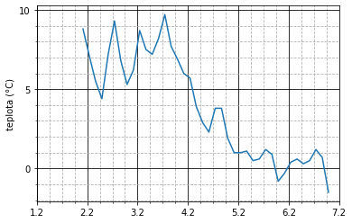

```python
%matplotlib inline

import matplotlib.pyplot as plt
import matplotlib.dates as mdates
import matplotlib.ticker as ticker

fig, axes = plt.subplots()  # pro lepší nastavení potřebujeme získat odkaz na objekt třídy `Axes`
axes.xaxis.set_major_formatter(mdates.DateFormatter("%-d.%-m"))  # nastavení formátu hlavních popisek
axes.yaxis.set_major_locator(ticker.MultipleLocator(5))  # nastavení intervalu hlavního kroku na ose `y`
axes.yaxis.set_minor_locator(ticker.MultipleLocator(1))  # nastavení intervalu vedlejšího kroku na ose `y`
axes.xaxis.set_minor_locator(mdates.HourLocator(interval=6))  # nastavení intervalu vedlejšího kroku `x`
axes.set_xlim(times[0].date(), times[-1].date() + datetime.timedelta(days=1))  # nastavení rozsahu osy `x`
axes.grid(True, which="major", color="k")  # nastavení hlavní mřížky
axes.grid(True, which="minor", linestyle="--")  # nastavení vedlejší mřížky

axes.set_ylabel("teplota (°C)") # název osy `y`

plt.plot(times, temperatures) # a nyní můžeme konečně graf vykreslit
```

Skript pro vykreslení grafu má jen jediný povinný řádek, a to poslední s voláním metody `plot`.Vše ostatní je konfigurace vzhledu. Abychom mohli vzhled grafu nastavit, potřebujeme získat objekt representující tu část obrázku, která je řízena osami (kromě vlastních os do ní patří i mřížka, různé popisky, atd.).

Voláním funkce `mathplotlib.pyplot.subplots` získáme dvojici hodnot: jedna representuje obrázek jako celek (třída `Figure`), druhá pak výše zmíněný prostor daný osami (třída `Axes`). První je označena proměnou `fig` (díle už ji nevyužíváme), druhá pak proměnou `axes`.

Nad objektem os lze volat velké množství metod, z nichž využíváme ty, které nastavují popisky os (angl. *ticks* a mřížky). U osy `y` nastavuje interval hlavního kroku (popisek) na 5 a vedlejšího na 1 (stupeň Celsia). Může se to zdát trochu složité, neboť parametrem těchto metod není číslo, ale objekt třídy `matplotlib.ticker.MultipleLockator`. *Matplotlib* však kromě fixního kroku podporuje i mnoho sofistikovanějších specifikací inetrvalů, které nemusí být konstantní.

U osy `x` nastavujeme interval vedlejších popisek na 6 hodin (interval hlavních popisek je automaticky 1 den, což nám vyhovuje). Upravíme i formát hlavních popisek (formát je shodný s metodou `datetime.datetime.strftime`, který již známe).

Poté nastavíme i mřížky (hlavní = *major* a vedlejší = *minor*). Specifikace vychází z frameworku Matlab a je pro začátečníky dost kryptická. Hlavní barvy jsou označeny jedním písmenem ('r' = *red*, 'b' = *blue*, černá je však `k`!), styl čar symbolicky pomocí běžných znaků ('--' je čárkovaní čára). Další možnosti viz např. https://python-graph-gallery.com/cheat-sheets/).

Zarovnání hlavních a vedlejších popisek na ose `x` vyžaduje, aby hodnoty na ose začínali v čase dělitelném šesti (0:00, 6:00, 12:00, 18:00). Zde je to dosaženo tím, že dolní limit je nastaven na půlnoc prvního dne (metoda `datetime.datetime` vrací objekt `datetime.date` representující půlnoc) a pro symetrii je nastaven i limit horní na půlnoc, která následuje za posledním časovým údajem (v případě půlnoci na následující půlnoc).

> **Úkol**: Zobrazte do jednoho grafu očekávaný tlak (přepočtený na hladinu moře) a vlhkost. Obě veličiny se liší v řádech proto použijte sekundární osu `y`.

> Rada: viz https://matplotlib.org/gallery/api/two_scales.html

```python
# tato část je téměř beze změny

import requests
import datetime

endpoint = "http://api.openweathermap.org/data/2.5/forecast"
params = {  # slovník parametrů
    "q" : "Dobříň", # jméno lokality (nahraďte za místo Vašeho pobytu)
     "appid" : get_api_key("/home/fiser/credentials/open_weather_map"),
    "mode" : "json" # formát výstupu
}

data= requests.get(endpoint, params).json()   # načtení JSON dat a jejich převod do slovníku

# extrakce do pole hodnot s liší jen v použitém jménu klíčů u tlaku a vlhkosti (chybí také přepočet)
times = [datetime.datetime.fromtimestamp(item["dt"]) for item in data["list"]]
pressures = [item["main"]["sea_level"] for item in data["list"]]
humidities = [item["main"]["humidity"] for item in data["list"]]

print(pressures)
print(humidities)
```

```
[1005, 1008, 1009, 1011, 1011, 1011, 1008, 1007, 1006, 1007, 1007, 1008, 1009, 1010, 1010, 1010, 1009, 1009, 1007, 1008, 1009, 1008, 1008, 1011, 1011, 1011, 1012, 1018, 1023, 1027, 1027, 1028, 1027, 1025, 1024, 1026, 1029, 1030, 1030, 1030]
[81, 87, 74, 75, 66, 58, 73, 93, 95, 84, 84, 87, 77, 62, 78, 82, 82, 80, 80, 80, 83, 69, 64, 78, 88, 89, 92, 96, 71, 72, 69, 73, 82, 79, 83, 95, 57, 48, 56, 61]
```

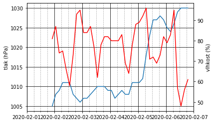

```python
%matplotlib inline

import matplotlib.pyplot as plt
import matplotlib.dates as mdates
import matplotlib.ticker as ticker

fig, axes = plt.subplots()  # pro lepší nastavení potřebujeme získat odkaz na objekt třídy `Axes`
axes.xaxis.set_major_formatter(mdates.DateFormatter("%-d.%-m"))  # nastavení formátu hlavních popisek
axes.xaxis.set_minor_locator(mdates.HourLocator(interval=6))  # nastavení intervalu vedlejšího kroku `x`
axes.set_xlim(times[0].date(), times[-1].date() + datetime.timedelta(days=1))  # nastavení rozsahu osy `x`
axes.grid(True, which="major", color="k")  # nastavení hlavní mřížky
axes.grid(True, which="minor", linestyle="--")  # nastavení vedlejší mřížky

axes.set_ylabel("tlak (hPa)") # název osy `y`

axes.plot(times, pressures)

axes2 = axes.twinx() # přidáme druhou osu
# a pak ji nastavíme
axes.set_xlim(times[0].date(), times[-1].date() + datetime.timedelta(days=1)) # nutno nastavit i zde!
axes2.set_ylabel("vlhkost (%)")

axes2.plot(times, humidities, color="r")  # červeně pro odlošení
```

Vložení sekundární osy se provádí voláním metody `twinx` na objektu hlavních os. Vrací nový objekt os, který je možné do určité míry kustomizovat nezávisle. Nastavení limitů osy `x` musí však být stejné (a musí se explicitně uvádět, jinak se zvolí automatické, které překryje nastavení u primárních os). Lze dokonce nastavit i vlastní mřížku (výsledek však vypada strašně, ale zkuste si to).

# 8. Representace dat

Python před uživateli skrývá detaily datové representace. Když vytvoříte seznam, tak vám nabídne metody resp., kterými můžete získávat informace o seznamu (např. délku seznamu, nalezení prvku v seznamu), číst a zapisovat jeho prvky (indexace) resp. se seznamem manipulovat (přidávat či odebírat prvky), apod. Vůbec vás nemusí jak je seznam representován v paměti.

To však je jen částečná pravda, neboť paměťová representace může výrazně ovlivnit efektivitu programu, tj.

1. rychlost vykonávání programu
2. spotřebu operační paměti (tj. kolik paměti se pro uložení seznamu použije).

Pokud jsou seznamy malé, pak si ve většině případů nemusíme s efektivotou lámat hlavu. Je v zásadě jedno pokud operace trvá 1 µs nebo 1 ms (1000× vice, obojí je ale pro člověka nepostřehnutelně malý časový okamžik). Stejně je u osobních počítačů v zásadě jedno, zda seznam zaujme 1 KiB nebo 1 MiB (1024× více).

## Časová složitost

V případě časové náročnosti výpočtu lze pro jednoduchost vycházet z toho, že doba vykonání programu je funkcí velikosti seznamu.

Podívejme se například na následující program, který vytváří seznamy seznam náhodně promíchaných hodnot 0 až $n-1$ (každá hodnota je tam obsažena jen jednou).

```python
from random import shuffle

def shuffled_range(n): # funkce vytvářející seznam
    rseq = list(range(n))
    shuffle(rseq)
    return rseq

# zjistíme čas a uložíme pro další zpracování
time_infos = []
ns = list(range(200_000,2_000_001, 200_000)) #seznam hodnot n, pro něž budeme měřit
for n in ns:
    print(n)
    t = %timeit -o shuffled_range(n) # měření rychlosti (výsledek se uloží do t)
    time_infos.append(t)
```

```
200000
141 ms ± 5.73 ms per loop (mean ± std. dev. of 7 runs, 10 loops each)
400000
302 ms ± 6.91 ms per loop (mean ± std. dev. of 7 runs, 1 loop each)
600000
463 ms ± 5.87 ms per loop (mean ± std. dev. of 7 runs, 1 loop each)
800000
637 ms ± 8.4 ms per loop (mean ± std. dev. of 7 runs, 1 loop each)
1000000
803 ms ± 2.93 ms per loop (mean ± std. dev. of 7 runs, 1 loop each)
1200000
982 ms ± 2.08 ms per loop (mean ± std. dev. of 7 runs, 1 loop each)
1400000
1.17 s ± 8.32 ms per loop (mean ± std. dev. of 7 runs, 1 loop each)
1600000
1.35 s ± 4.1 ms per loop (mean ± std. dev. of 7 runs, 1 loop each)
1800000
1.53 s ± 14.3 ms per loop (mean ± std. dev. of 7 runs, 1 loop each)
2000000
1.69 s ± 12.9 ms per loop (mean ± std. dev. of 7 runs, 1 loop each)
```

Pomocí jupyterovského »magického«`%timeit` lze změřit čas provedení příslušného řádku (včetně relativně klíčové informace o směrodatné odchylce). Přepínač `o` zajistí, že se vrátí objekt, representující měření (a je pak uloženo do proměnné `t`).

Měření bylo provedeno pro seznamy s délkou 200 000 a 2 milióny položek (včetně, proto je uvedena horní mez + 1) s krokem 200 000.

```python
# velikosti seznamů

import matplotlib.pyplot as plt
from matplotlib.ticker import EngFormatter
import numpy as np

def show_graph(x,y, polynomial_degree):
    # nastavení popisek
    fig, ax = plt.subplots()
    ax.xaxis.set_major_formatter(EngFormatter())

    plt.plot(x,y, "o") # graf závislosti (body)
    plt.grid(True)

    z = np.polyfit(x, y, polynomial_degree) # polynomiální
    p = np.poly1d(z) # vytváří funkci repr. lineární polynom
    plt.plot(x, p(x),"r--") # vykreslí trend
    print(p)
```

```
8.704e-07 x - 0.05154
```

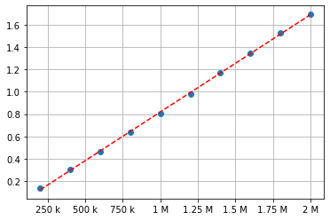

```python
t = [info.average for info in time_infos] # zajímá nás jen  průměrný čas
show_graph(ns, t, 1)
```

Jak lze vidět z grafu, roste doba vykonávání lineárně a to rychlostí cca 0,9 sekundy na milion položek (hodnota závisí na rychlosti počítače). Abolutní člen, který by měl vyjadřovat konstantní režii (čas inicializace apod.) je větší seznamy zanedbatelný (v mém případě je z důvodů nepřesností dokonce záporný).

Pokud zanedbáme absolutní člen, pak je navíc zřejmé, že pokud se počet položek zdvojnásobí (např. z 500k na 1M) tak se zdvojnásobí i čas vykonávání (a zde ani nezávisí na směrnici).

Závislost mezi velikostí seznamu a dobou zpracovávání nemusí být jen lineární. Podívejme se například na elementární způsob řazení (třídění) tj. algoritmu, který seznam přeuspořádá, tak že jsou prvky umístěny od nejnižšího po nejvyšší (lze uvažovat i opačný směr). Algoritmus **řazení výběrem** vychází z jednoduché úvahy, že nejdříve najdeme nejmenší prvek ten vyměníme s prvním prvkem (pokud už není první), pak najdeme nejmenší prvek ve zbytkovém seznamu a prohodíme ho z druhým. Následuje nalezení nejmenšího prvku v podseznamu od třetího prvku, a tak pokračuje dál dokud se nesetříděný zbytek seznamu neomezí na jediný prvek.

```python
def select_sort(s):
    for i in range(len(s)-1): # od jakého prvku hledáme minimum
        min_index = i
        for j in range(i, len(s)):
            if s[j] < s[min_index]:
                min_index = j
        s[i], s[min_index] = s[min_index], s[i]
```

```python
s = shuffled_range(20) # promíchaná posloupnost čísel
print(s)  # pro jistotu vypíšeme (pravděpodobnost, že je setříděná je ale malá)
select_sort(s) # setřídíme
print(s) # vypíšeme setříděné
```

```
[9, 13, 15, 7, 0, 3, 16, 17, 10, 18, 6, 8, 19, 2, 11, 14, 5, 4, 12, 1]
[0, 1, 2, 3, 4, 5, 6, 7, 8, 9, 10, 11, 12, 13, 14, 15, 16, 17, 18, 19]
```

Pravděpodobnost je rovna pravděpodobnosti, že nastane jedna konkrétní permutace čísel mezi všemi možnými, jichž je $n!$ tj. $\frac{1}{n!}$. Pro $n = 20$ je to cca $4,11\cdot 10^{-19}$.

Pro zištění doby běhu použijeme opět magický příkaz `timeit`. Liší se jen rozsah hodnot a název volané metody.

```python
time_infos2 = []
ns2 = list(range(2_000,10_001, 1_000)) #seznam hodnot n, pro něž budeme měřit
for n in ns2:
    print(n)
    s = shuffled_range(n)
    t = %timeit -o select_sort(s) # měření rychlosti (výsledek se uloží do t)
    time_infos2.append(t)
```

```
2000
138 ms ± 1.29 ms per loop (mean ± std. dev. of 7 runs, 10 loops each)
3000
303 ms ± 4.6 ms per loop (mean ± std. dev. of 7 runs, 1 loop each)
4000
536 ms ± 4.57 ms per loop (mean ± std. dev. of 7 runs, 1 loop each)
5000
835 ms ± 6.26 ms per loop (mean ± std. dev. of 7 runs, 1 loop each)
6000
1.2 s ± 4.59 ms per loop (mean ± std. dev. of 7 runs, 1 loop each)
7000
1.64 s ± 8.95 ms per loop (mean ± std. dev. of 7 runs, 1 loop each)
8000
2.16 s ± 24.2 ms per loop (mean ± std. dev. of 7 runs, 1 loop each)
9000
2.82 s ± 89.8 ms per loop (mean ± std. dev. of 7 runs, 1 loop each)
10000
3.78 s ± 220 ms per loop (mean ± std. dev. of 7 runs, 1 loop each)
```

Pro zobrazení použijeme naší funkcí `show_graph`, které přidáme nově získaná pole `ns2` (počet položek řazeného pole) a `t2` (průněrný čas běhu). Nejdříve zvolíme lineární trend, jako v předchozím příkladě.

```
0.0004362 x - 1.127
```

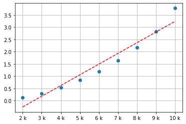

```python
t2 = [info.average for info in time_infos2]
show_graph(ns2, t2, 1)
```

Je zřejmé, že lineární trend, příliš neodpovídá. Body vyjadřující čas provedení pro jednotlivá $n$ mají spíše tvar paraboly. Proto zkusíme trend stupně 2 (kvadratický).

```
           2
4.754e-08 x - 0.0001342 x + 0.2671
```

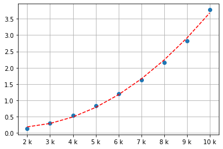

```python
t2 = [info.average for info in time_infos2]
show_graph(ns2, t2, 2)
```

To už vypadá mnohem lépe. I v tomto případě je možné zenedbat absolutní člen a nyní i člen lineární. Čas provedení je pak řádově $4,75\cdot 10^{-8}n^2$. Nyní už je jasné proč jsme nezjišťovali čas pro $n = 200\,000 \ldots 2\,000\,000$. I pro nižší z těchto hodnot by to trvalo cca 1900 vteřin, je téměř 32 minut. Pro 2 milióny položek (což je desetkrát více) by to trvalo 10×10 déle tj. přes 52 hodin.

Jak lze tedy vidět, roste čas vykonávání promíchávání lineárně zatímco čas třídění kvadraticky.

Tuto skutečnost, že matematicky vyjádřit tzv. asymptotické časové složitosti a pomocí Landauovy „O“ notace. Pokud funkce růstu můžeme od jistého (typicky velkého) čísla z obou stran omezit nějakými dvěma lineárními funkcemi, pak budeme tvrdit, že má lineární asymptotickou časovou složitost a budeme to značit $O(n)$ (čteno velké „o“ „en“).

Podobně lze zavést i časovou složitost (slovo asymptotická se běžně vynechává) kvadratickou $O(n^2)$.

To lze zobecnit na polynomy libovolného řádu. Pokud čas vykonávání roste nějakou polynomiální funkcí $a_n x^n + a_{n-1} x^{n-1} + \cdots + a_0$ je odpovídající časová složitost $O(x^n)$ (typicky se setkáváme běžně jen se složitostí kubickou.

Kromě polynomiální složitosti se v praxi setkáváme i s dalšími typy asymptotických složitostí.

| složitost | označení |
| --- | --- |
| $O(1)$ | konstantní |
| $O(log(n))$ | logaritmická |
| $O(n)$ | lineární |
| $O(n\log(n))$ | loglineární |
| $O(n^2)$ | kvadratická |
| $O(n^3)$ | kubická |
| $O(a^x)$ | exponenciální |

**Konstantní časovou složitost** mají operace, jejichž doba vykonávání nezáleží na počtu prvků kolekce. V případě seznamu mají tuto časovou složitost tři klíčové operace: zjištění délky seznamu, indexace (nalezení i-tého prvku) a přidávání prvku na konec seznamu.

> **Úkol**: Ověřte časovou složitost výše uvedených operací pomocí benchmarkingu.

Další typickou časovou složitostí u seznamů je ta **lineární**. Je spojena s operacemi, které přidávají či odebírají prvky uvnitř seznamu a které tudíž vyžadují posunutí prvků (musí se posunout všechny položky za vkládaným či vyjímaným, tj. průměrně $n/2$ prvků). Lineární časovou složitost má i vyhledávání, zda je nějaká hodnota obsažena v seznamu (operátor `in`) respektive na jaké pozici (metoda `index`). I zde je to jasné neboť je nutné projít buď všechny prvky (nejhorší případ), nebo alespoň půlku (průměrný případ).

> **Úkol**: Ověřte časovou složitost operací s lineární složitostí, Vytvářejte promíchané seznamy čísel a pak:
> 1. hledejte náhodný prvek, který se v nich nachází
> 2. hledejte prvek, který se v nich nenachází
> 3. vyjímejte prvek v náhodné pozici (příkaz `del`)
> 4. vyjímejte náhodný prvek podle jeho hodnoty (tj. nějaké číslo, které se v seznamu určitě nachází)
> 5. vkládejte prvek na náhodnou pozici (kamkoliv v seznamu)

**Kvadratickou časovou složitost** nemá žádná ze standardních operací nad seznamem (ani řazení `sort` viz níže), může se však vyskytnout v případě, že se provede průměrně $n$ operací s lineární složitostí.

Příkladem budiž například výmaz určitých položek seznamu, kde je počet odstraněných položek proporcionální k velikosti seznamu (tj. například je proveden výmaz cca poloviny položek).

```python
from random import normalvariate
def random_list(n, μ, σ):
    # pomocná metoda pro generování seznamu s náhodným obsahem
    return [normalvariate(μ, σ) for _ in range(n)]

def remove_outliers(lst, min, max):
    for i in reversed(range(len(lst))):
        if not (min <= lst[i] <= max):
            del lst[i]

s = random_list(10, 0, 1)
print(s)
remove_outliers(s, -1.0, 1.0) # z teorie je zřejmé že bude vymazána cca třetina položek
print(s)
print(len(s))
```

```
[1.3076182847500615, -0.19455352971772377, 1.3238986795848862, 1.0930187324504679, 0.03098734857896747, 0.32516505339826896, 1.4670071132597895, -0.6582798382195861, -0.10529423804465683, -0.48349124646366154]
[-0.19455352971772377, 0.03098734857896747, 0.32516505339826896, -0.6582798382195861, -0.10529423804465683, -0.48349124646366154]
6
```

První pomocná funkce generuje seznam, jenž obsahuje náhodná čísla z normálního rozdělení s požadovanou střední hodnotou a směrodatnou odchylkou. Tato funkce má časovou složitost $O(n)$ neboť přidává $n$ s časovou složitostí $O(1)$.

Hlavní funkce, pak ze seznamu odebírá prvky, které neleží v intervalu $[min, max]$. což se typicky používá pro tzv. odlehlé body (*outliers*). Funkce prochází (pozpátku!) seznam a pomocí příkazu `del` vymazává prvky. Pro algoritmus je klíčové, že prvky jsou odmazávány v opačném směru, neboť dopředný algoritmus posouvá indexy ještě nezkontrolovaných prvků.

> **Úkol**: Navrhněte algoritmus, který dané prvky odstraní s lineární časovou složitostí.

```python
[p for p in random_list(10, 0, 1) if -1 <= p <= 1]
```

```
[0.030537618343014095,
 -0.6595644000080445,
 0.5814670660086998,
 -0.38763018363506624,
 0.8912492207664056]
```

> **Otázka**: Jaká je časová složitost spojení obou kroků tj. generování náhodného seznamu a následné odstranění prvků výmazem.

**Logaritmická časová složitost** je typická pro některé algoritmy vyhledávání. Ve standardním rozhraní seznamu však není zastoupena. Klasickým příkladem je binární vyhledávání (https://en.wikipedia.org/wiki/Binary_search_algorithm). V Pythonu je implementována v modulu `bisect`.

Binární vyhledávání funguje jen na seřazených posloupnostech. Klíčovým úkolem je proto zajistit, že je posloupnost udržována seřazená (). To lze zajistit dvěma způsoby:

1. nové položky jsou vkládány na správná místa tzv. vřazování (každé vkládání má složitost $O(n)$, neboť se obecně vkládá i dovnitř seznamu, pokud je vstup už seřazen ve správném směru, pak se je ale časová složitost konstantní!)
2. pole je před vyhledáváním seřazeno (to však má u běžně používaných algoritmů časovou složitost $O(n\log(n))$)

Celková složitost vyhledávání je tak dána vzorem vkládání a hledání.

1. pokud se více vkládá než hledá resp. průběžně vkládání průběžně střídá s vkládáním a jeho podíl není zanedbatelný, tak výrazně převažuje režie vkládání a jediným alespoń trochu akceptovatelným algoritmem je vřazování (vkládá se $n$ položek s časovou složitostí $O(n)$ tj, celková složitost vkládání je $O(n^2)$), vyhledávání lze zanedbat. To však platí jen v případě, že máme k dispozici jen seznam. Použití slovníku vede téměř vždy k mnohem lepšímu výsledku (viz níže).
2. hodnoty se nejdříve najednou vloží, a pak se nad nimi masivně vyhledává (počet vyhledávání je řádově větší než počet prvků). Příkladem jsou například jízdní řády. Zde se vyplatí po vložení seznam, setřídit a pak využívat binární vyhledávání (hlavně tehdy, když je seznam extrémně rozsáhlý). Celková složitost je $O(n \log(n))$
3. Výrazně převažují vyhledávání, do seznamu se však občas vkládají nové položky. Příkladem je seznam uživatelů nějaké webové služby. Uživatelé se často vyhledávají, ale jen občas přibývají noví. Zde je nejvhodnější strategií vřazování. Časová složitost je dáná opět primárně vyhledáváním ($O(n \log(n))$).

> **Úkol:** Pomocí modulu `bisect` implementujte vřazování a binární vyhledávání (modul nabízí zbytečně složité i když obecně použitelné funkce, implementace vřazování a vyhledávání je však uvedena na konci dokumentace). Následně porovnejte s efektivitou množiny (`set` viz níže).

**Loglineární časová složitost** $O(n\log(n))$ je další typickou složitostí. Tuto složitost mají především všechny běžně používané univerzální řadící (třídící) algoritmy, a to včetně třídícího algoritmu užívaného v Pythonu (univerzální = použitelné na libovolný datový typ s definicí uspořádání). Python aktuálně používá nepříliš známý a dosti komplexní algoritmus *Timsort* (https://en.wikipedia.org/wiki/Timsort), který má v průměrném případě (tj. například pro náhodně promíchané) prvky složitost loglineární. Pokud je však vstup alespoň částečně seřazen, může dosahovat i lineární časovou složitost.

Posledním běžným typem časové složitosti nad kolekcemi je **exponenciální časová složitost**, kde čas roste podle křivky ($a^n$) kde $a>1$ (ostatní členy lze s klidem zanedbat). Základní charakteristikou této časové složitosti, je to že čas roste s každám dalším $a$ násobně. $a$ je v praxi relativně malé číslo (ale vždy větší než 1!), takže růst je zpočátku pomalý, ale již v řádu malých desítek rychle čas provedení rychle roste (vteřiny, minuty), pro vyšší desítky se už výpočet nedá provádět v reálném čase (tj. v řádu hodin či dnů). Pro velikosti v řádu stovek už nemusí stačit ani očekávaný věk sluneční soustavy.

Exponenciální časová složitost je typická pro algoritmy, které procházejí všechny kombinace prvků (resp. jejich $k$-procentní část). V mnoha případech existují sofistikovanější algoritmy, které úlohu řeší v polynomiálním čase (tj. $O(n^k)$). Existují však i algoritmy, kde není takové řešení známo, resp. je vysoce pravděpodobné (i když nikoliv dokázané), že neexistuje (tzv. https://cs.wikipedia.org/wiki/NP-%C3%BAplnost). Nejznámější z těchto úloh je problém obchodního cestujícího a problém batohu.

V těchto případech se musíme spokojit s optimalizací exponenciálního růstu (tj. nižším $a$, které umožňuje aplikovat je i na o něco delší seznamy). Například pokud řešíme problém obchodního cestujícího hrubou silou tak jsme omezeni skutečně jen na malé desítky, optimalizovaný algoritmus pokrývá i malé stovky). Další možností je vyhledání řešení, které není optimální a ale dostatečně s k němu blíží (viz například feromonový algoritmus pro řešení problému obchodního cestujícího).

### Obecné závěry o časové složitosti pro začátečníky

Časovou složitost některých algoritmů lze určit aplikací dvou pravidel:

- algoritmus využívající $m$ vnořených cyklů, z nichž každý iteruje $k * n$-krát, kde $k > 0$ nebo do hodnoty $k * i$-krát, kde $i$ je hodnota nadřízeného cyklu má složitost $O(n^k)$
- pokud je v algoritmu více lineárních kroků, pak je celková časová složitost dána krokem s limitně nejvyšší složitostí.

U některých algoritmů je však určení časové složitosti náročnější a u určité části je to vyšší matematika (a programátor se tak musí spokojit s výsledky matematiků).

Další komplikace přinášejí algoritmy, jejichž časová složitost závisí na uspořádání dat v kolekci (resp. na vstupu). V tomto případě se nejčastěji uvádí tzv. **průměrná složitost**, kterou si lze představit jako časovou složitost, která převažuje u většiny možných vstupů. Typicky je to složitost nad náhodným obsahem. Existuje však i **složitost v nejlepším případě** (kdy je vstup uspořádán tak, že algoritmus funguje nejefektivněji), a **složitost v případě nejhorším**.

Zřejmé je to například u vyhledávání. Pokud je hledaný prvek vždy na prvním místě a jen výjimečně na posledním, pak je časová složitost triviálního algoritmu konstantní. Je-li naopak vždy na konci je časová složitost shodná s průměrným případem (i když je v průměru čas hledání dvojnásobný!). U řadících algoritmů je problém podobný, jen je často mnohem obtížnější definovat vstupy vedoucí k nejlepší či nejhorší časové složitosti. U některých algoritmů s běžnou časovou složitostí $O(n\log(n))$ mohou nevhodná data vést ke složitosti $O(n^2)$. To může vést k tomu, že výpočet trvající zlomky vteřin bude trvat celé minuty či hodiny.

V praxi je nutno zohlednit skutečnost, že klíčová bývá časová složitost v nejhorším případě, neboť častým požadavkem bývá maximální doba odezvy. Navíc pravděpodobnost případů s nejhorší časovou složitostí může být více, než by vyplývalo z rovnoměrného rozložení.

- speciální rozložení jous častější z důvodu potenciálního předzpracování. Relativně častá jsou částečně uspořádaná vstupní data, která u některých řadících algoritmů vedou k lineární složitosti (`Timsort`), u jiných naopak ke kvadratické (`Quicksort`).
- podíl *nevhodných* dat může změnit útočník (posíláním *nevhodně* uspořádaných dat může vést ke zvýšení doby odezvy, tj. je to přípklad DOS útoku).

Hlavním důvodem, proč je nutné znát časové složitosti, je odhad použitelnosti algoritmů s ohledem na velikost zpracovávaných dat. Z tohoto hlediska lze časové složitosti rozdělit do čtyř kategorií.

**operace je i pro velká dat provedena téměř okamžitě** (konstatní a logaritmická). hlavím problémem je tak spíše nalezení dostatečně velkého a dostatečně rychlého úložiště (tj. kritické jsou přístupové časy k paměti, případné swapování) **operace jsou netolerovatelně pomalé jen pro řád stovek miliónu, či spíše ještě větší** (lineární, loglineární), což lze u některých typů dat vyloučit (například počet zaměstananců jen stěží překoná hranici stovek miliónů) **operace, jejichž nasazení je nutno zvažovat již na hranici tisíců či desetitisíců** (kvadratické a kubické), zde už je časová složitost faktorem, který nejvíce ovlivňuje nasazení. Lze počítat **exponenciální časová složitost** je akceptovatelná jen pokud je počet prvků malý a striktně omezen.

Při hodnocení algoritmů jsou kromě prosté časové složitosti důležité i další apekty, které se ve formalismu časové apekty zanedbávají.

- nižší členy polynomu vyjadřujícího časovou závislost především konstantní člen = může výrazně ovlivnit efektivitu především u malých kolekcí (řádově do malých stovek)
- násobící koeficient = může výrazně ovlivnit využitelnost a to i pro velká data, vyšší koeficient znamená, že algoritmus je vždy pomalejší než jiné se stejnou složitostí ale jiným násobitelem) a i pro velká data dokonce může být pomalejší než algoritmus s nižší časovou složitostí.

Jako případovou problémů s interpretací časové složitosti lze uvést již dříve zmíněný vestavěný algoritmus třídění.

### Problémy se zjištěním a interpretací časové složitosti

Budeme měřit rychlost setřídění náhodně promíchaného seznamu, tj. pokusíme se odhadnbout průměrnou časovou složitost.

Nyní však nezvolíme aritmetickou posloupnost postupně rostoucích hodnot $n$ ale posloupnost geometrickou, s hodnotami $2^{15}, 2^{16}, 2^{17}, \ldots, 2^{24}$

```python
time_infos3 = []
ns3 = [2**n for n in  range(15,25)] #seznam hodnot n, pro něž budeme měřit
for n in ns3:
    print(n)
    s = shuffled_range(n)
    t = %timeit -o s.sort() # měření rychlosti (výsledek se uloží do t)
    time_infos3.append(t)
```

```
32768
168 µs ± 1.63 µs per loop (mean ± std. dev. of 7 runs, 10000 loops each)
65536
345 µs ± 5.42 µs per loop (mean ± std. dev. of 7 runs, 1000 loops each)
131072
692 µs ± 14.5 µs per loop (mean ± std. dev. of 7 runs, 1000 loops each)
262144
1.72 ms ± 31.3 µs per loop (mean ± std. dev. of 7 runs, 1000 loops each)
524288
3.63 ms ± 23.9 µs per loop (mean ± std. dev. of 7 runs, 100 loops each)
1048576
7.35 ms ± 26.5 µs per loop (mean ± std. dev. of 7 runs, 1 loop each)
2097152
14.8 ms ± 33.7 µs per loop (mean ± std. dev. of 7 runs, 1 loop each)
4194304
29.1 ms ± 38.1 µs per loop (mean ± std. dev. of 7 runs, 1 loop each)
8388608
58.4 ms ± 228 µs per loop (mean ± std. dev. of 7 runs, 1 loop each)
16777216
117 ms ± 431 µs per loop (mean ± std. dev. of 7 runs, 1 loop each)
```

```
6.999e-09 x - 9.823e-05
```

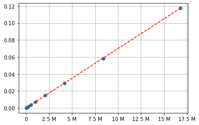

```python
t3 = [info.average for info in time_infos3]
show_graph(ns3, t3, 1)
```

Závislost se na první pohled jeví jako lineární. Navíc násobitel je velmi nízký (7 miliardtin). Tj. i pole o velikosti stomiliónů položek (zaujímající paměť v řádu GiB) se setřídí za méně než sekundu. Python je obecně dost pomalý jazyk, ale třídění je implementováno v nízkoúrovňovém jazyce a je ručně optimalizováno pro třídění běžných hodnot včetně využití `insertion sort` pro malé seznamy (to mimo jiné znamená, že nemá prakticky smysl používat jiný algoritmus, především pak algoritmus napsaný v Pythonu a to ani pro malé seznamy).

Podle dokumentace je však složitost třídění $O(n \log(n)$ a i teorie tvrdí, že neexistuje žádný univerzální třídící algoritmus s lepší časovou složitostí. Proto se pokusíme nalézt odpovídající funkci (je třeba využít jinou funkci z balíku `scipy`).

```python
import numpy as np
from scipy.optimize import curve_fit

def func(x, a): # funkce parametrizovaná parametrem `a`
    return a * x * np.log(x)

par, _ = curve_fit(func, ns3, t3)
# najde takové `a`, že součet druhých mocnin odchylek je minimální
print(par)
```

```
[4.25816254e-10]
```

Seznam obsahuje optimální hodnoty parametrů v pořadí jak jsou uvedeny ve funkci (v našem případě je jen jeden parametr `a` a je tedy roven cca 4.26e-10). Nyní zakreslíme jak lineární tak loglineární trend a pro porovnání i trend operace pro promíchávání hodnot, jenž je také lineární.

Pro zobrazení většího rozsahu hodnot využijeme logaritmickou škálu jak na ose $x$ (se základem 2), tak na osy $y$ (se základem 10$).

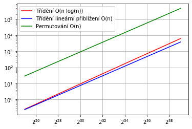

```python
x = np.fromiter((2**i for i in range(25,40)), dtype=np.float64)
fig, ax = plt.subplots() # získání objektu representujícího graf s osami
ax.set_xscale('log', basex=2) # logaritmická `x`
ax.set_yscale('log') # logaritmická `y`
plt.grid(True)
plt.plot(x, func(x, *par), "r", label="Třídění O(n log(n))")
plt.plot(x, 6.999e-9*x, "b",label="Třídění lineární přiblížení O(n)")
plt.plot(x, 8.704e-07*x, "g", label="Permutování O(n)")
plt.legend()
```

## Množina a slovník

### Množina

Vyhledávání patří mezi nejdůležitější operace nad libovolnou kolekcí. Vyhledávání v seznamu má ale časovou složitost $O(n)$ a je tak pro větší kolekce příliš pomalé (hlavně tehdy pokud, se vyhledává často).

Z tohoto důvodu existují kolekce optimalizované na vyhledávání.

Nejjednodušší je **množina** (*set*), do níž můžeme vkládat libovolné objekty, pro něž je rozumně definováno testování shody (rovnost).

Množiny lze vytvářet dvěma zásadními způsoby:

a) přímým výčtem ve složených závorkách

```python
m1 = {1, 2, 3}
# výjimkou je prázdná množina kterou lze vytvořit jen voláním bezparametrického konstruktoru
empty = set()
```

b) vyplněním prostřednictvím iterátoru (včetně přesunu z jiné kolekce)

```python
m2 = set(range(100))
m3 = set([1,2,3])
# resp. pomocí množinové komprehenze
m4 = {i for i in range(100)}
m5 = {str(i) for i in range(100)}
```

Nad množinou se nejčastěji provádějí následující operace:

- vyhledávání (operátor `in`) s časovou složitostí $O(1)$
- výmaz prvku (metody `remove` nebo `discard`)
- vkládání (metody `add` a `update`) s časovou složitostí $O(1)$
- iterování (např. v cyklu `for`) s časovou složitostí $O(n)$ (projití všech prvků)
- základní množinové operace *sjednocení* (`union` resp. `update`), *průnik* (`intersetion`) a *rozdíl* (`difference`) vše s časovou složitostí $O(n)$, kde $n$ je je délka kratší z množin (průnik) resp. součet jejich délek.
- operace pro testování podmnožin `issubset` resp. `issuperset` (časová složitost je opět $O(n)$)

Zajímavé je především vyhledávání s časovou složitostí $O(1)$ . To je téměř zázračné, protože to znamená, že vyhledávání mezi miliardou objektů (například lidí) je stejně rychlé jako vyhledávání mezi desítkou objektů osob.

> **Úkol**: Uložte do množiny aktuální seznam názvů článků anglické Wikipedie, který je dostupný na URL http://dumps.wikimedia.org/enwiki/latest/enwiki-latest-all-titles-in-ns0.gz (doporučuji nejdříve stáhnout a pak otevírat jako soubor). Zjistěte počet článků a ověřte vyhledávací čas a porovnejte s časem vyhledávání v seznamu o několika málo položkách. Rada: Pro otevření kompromovaného `gzip` souboru použijte funkci `open` z modulu `gzip` (chovás se stejně jako vestavěná funkce `open` jen provádí příslušnou komprimaci či dekomprimaci.

```python
import gzip

if not titles:  # při opakovaném spuštění není potřeba
    with gzip.open("/home/fiser/data/enwiki-latest-all-titles-in-ns0.gz", "rt") as f:
        titles = set(f) # soubor
print(len(titles))
%timeit "Elbe" in titles
```

```
15317499
42.4 ns ± 2.82 ns per loop (mean ± std. dev. of 7 runs, 10000000 loops each)
```

```python
reky = {"Labe", "Vltava", "Ohře", "Morava", "Dyje"}
%timeit "Morava" in reky
```

```
32.6 ns ± 2.2 ns per loop (mean ± std. dev. of 7 runs, 10000000 loops each)
```

Zázraky však nejsou v reálném světě zadarmo. Slovník využívá tzv. **hashovací tabulku**, která ve své základní podobě předpokládá, že předem známe počet ukládaných hodnot (označme ho $n$)

Dále zvolme číslo $m$ takové, že je řádově shodné či větší než $n$ (tj. například $\frac{m}{n} = k$ je větší než 0,5).

Dále je potřeba

- zvolit funkcí (tzv. hashovací), která
  1. mapuje hodnoty (objekty) na čísla v intervalu 0 až $m$
  2. zajišťuje, že čísla odpovídající ukládaným hodnotám jsou rovnoměrně rozmístěna v intervalu 0 až $m$ (předpokládá se, že se ukládané hodnoty se neopakují)
- alokovat hashovací tabulku tj. (indexovatelný) seznam obsahující $m$ podseznamů (na začátku jsou prázdné)

Při vložení hodnoty do hashovací tabulky se na hodnotu nejprve aplikuje hashovací funkce. Výsledek se použije jako index do hashovací tabulky tj. hodnota se uloží na konec podseznamu s s příslušným indexem. Složitost je evidentně $O(1)$, protože výpočet hashovací funkce nezávisí ana $n$ ani na $m$ a konstantní čas je i čas přidání na konec seznamu.

Při vyhledávání se opět nejdříve vypočte hashovací hodnota. Pak stačí prohledat příslušný podseznam (tj. podseznam s indexem rovným výsledku hashovací funkce). Složitost je opět $O(1)$ neboť konstantní je jak výpočet hashovací funkce tak prohledání podseznamumu, který má nejvýše $\left\lceil\frac{1}{k}\right\rceil$ prvků (předpokládáme rovnoměrné rozmístění), tj. například nejvýše dva pro $k>0.5$.

Vyzkoušíme si vlastní implementovat vlastní verzi hashovací tabulky (jen pro didaktické účely, vestavěná verze je mnohem efektivnější). Navíc naše verze bude zpočátku omezena jen na ukládání čísel, protože pro ně existuje přirozená hashovací funkce, zbytek po dělení hodnoto $m$ (což je velikost hashovací tabulky).

```python
class HashTable:
    def __init__(self, m):
        self.table = [[] for _ in range(m)] # m-prázdných podseznamů
        self.m = m
    def add(self, x):
        h = x % self.m # hashovací funkce
        self.table[h].append(x)
    def __contains__(self, x):
        h = x % self.m # stejná hashovací funkce
        return x in self.table[h]
    def __str__(self): # výpis pro ladění
        import pprint # std. modul pro 'hezký' výpis
        return pprint.pformat(self.table)
```

Pro otestování zkusíme vytvořit hashovací tabulku (tj. naši implementaci slovníku) a naplnit ji náhodnými čísly. Zvolíme $n=100$, $m=50$ (tj $k=0{,}5$).

```python
import random

ht = HashTable(50)
for _ in range(100):
    ht.add(random.randint(0, 1_000))
print(ht)
```

```
[[450],
 [551, 501, 601, 751],
 [],
 [853, 553, 103, 53],
 [54, 4, 954, 504],
 [55, 805, 105],
 [706],
 [157, 307],
 [758, 258, 758],
 [609, 359, 909, 209],
 [260, 110, 610],
 [811],
 [],
 [363],
 [264, 114],
 [415],
 [766],
 [467, 817],
 [318, 268],
 [],
 [20, 20, 670, 120],
 [21, 471],
 [],
 [523, 973],
 [424, 774],
 [225],
 [726, 926, 476],
 [477, 927, 827],
 [778, 478, 728],
 [479],
 [380, 30],
 [381],
 [132],
 [383, 183],
 [534, 934, 584],
 [685, 985],
 [36],
 [587, 187, 587, 137, 37],
 [38, 188, 188, 688, 888, 288],
 [],
 [],
 [591],
 [292, 992],
 [543, 743, 943, 443],
 [494, 694],
 [495, 395, 295],
 [196, 996],
 [447],
 [98],
 [249]]
```

> **Úkol**: Aktuální implementace neřeší příliš vvícenásobné vkládání stejního čísla. Doplňte program tak, aby při se při opakovaném vkládání číslo v daném podseznamu objevilo jen jednou. Jak se tím ovlivní časová složitost.

Jak si můžete všimnout tak čísla nejsou rozložena zcela rovnoměrně, ale i tak je délka nejdelšího podseznamu výrazně menší než $n$ (při testovacím běhu byla délka největšího podseznamu rovna 6). To je platí v případě, že jsou vkládána náhodná čísla. Pokud vložíme čísla méně náhodná, pok je situace horší:

```python
ht = HashTable(50)
for _ in range(100):
    ht.add(random.randint(0, 1_000) * 10) # náhodné násobky desítí
print(ht)
```

```
[[8700,
  4400,
  12800,
  2900,
  6600,
  16900,
  14600,
  10400,
  11300,
  5800,
  6000,
  16200,
  5300,
  19000,
  8000,
  4000,
  13400,
  12400,
  7600,
  18100,
  9200,
  19200,
  12600,
  9300,
  2200],
 [],
 [],
 [],
 [],
 [],
 [],
 [],
 [],
 [],
 [2560,
  11160,
  13460,
  7760,
  10460,
  17160,
```

[output cut: 90 more lines]

```
  11240,
  8040,
  8340,
  4940,
  12140,
  3040],
 [],
 [],
 [],
 [],
 [],
 [],
 [],
 [],
 []]
```

Hodnoty jsou nyní soustředěny jen do těch položek, jež jsou dělitelné deseti a jej jich tak v seznamu mnohem větší počet (průměrně 20). Formálně je to sice stále $O(1)$ (počet = $\frac{10}{k}$ což nezávisí na $n$) ale tato fixní hodnota je pro menší počet položek srovnatelná s vyhledáváním v seznamu, tj. výraznější zrychlení se projeví, až pro velká $n$.

Všimněte si, že omezení vstupu na čísla dělitelná deseti může nastat v praxi docela často, neboť čísla jsou běžně zaokrouhlována. Efekt je přitom výrazný (doba vyhledávání se prodlouží 10x)

> **Otázka**: Jaká je časové složitost, pokud vložíme jen hodnoty dělitelné 100.

V praxi je nutno vycházet z toho, že neexistuje žádná univerzálně použitelná hashovací funkce a to ani v rámci hodnot jednoho typu (a už vůbec ne pro hodnoty různých typů). Zvláště nepříjemná je situace u řetězců, kde je obtížné najít funkci, která by rovnoměrně rozmisťovala např. slova přirozeného jazyka (včetně např. jmen).

Python definuje pro všechny porovnatelné a nemodifikovatelné objekty *obecnou hashovací funkci* pomocí speciální metody `__hash__` (lze ji přímo volat pomocí vestavěné funkce `hash`), která pro libovolnou hodnotu vrací číslo v rozsahu $-2^n$ až $2^n$ (kde $n$ závisí na implementaci, typicky je to dnes 63). Konkrétní hashovací funkce má následně tvar `hash(x) % m`.

```python
hash(5) # pro malá čísla je univerzální hashovací funkce identita
```

```
5
```

```python
print(hash("Sílor"))
print(hash("Dalibor"))
```

```
-4652231863778686888
-3605212863001359283
```

> **Úkol**: Upravte naši implementaci naší třídy `HashTable` tak aby využívala vestavěnou obecnou hashovací funkci.

```python
class HashTable:
    def __init__(self, m):
        self.table = [[] for _ in range(m)] # m-prázdných podseznamů
        self.m = m
    def add(self, x):
        h = hash(x) % self.m # hashovací funkce
        if not x in self.table[h]:
            self.table[h].append(x)
    def __contains__(self, x):
        h = hash(x) % self.m # stejná hashovací funkce
        return x in self.table[h]
    def __str__(self): # výpis pro ladění
        import pprint # std. modul pro 'hezký' výpis
        return pprint.pformat(self.table)
```

Výsledná rychlost vyhledávání je kromě volby hashovací funkce ovlivněna i velikostí hashovací tabulky (v našem označení $m$). Pokud zvolíme $m$ dostatečně velké (typicky větší než očekávané $n$), pak většina řádků tabulky obsahuje nanejvýše jednu položku. Jen občas dochází k tzv. kolizím, kdy jsou dvě hodnoty namapovány na stejný řádek. Zvětšení $m$ ale není zadarmo, neboť mnohé řádky jsou naopak prázdné a paměť, která je pro ně alokována zůstává ladem.

> **Úkol**: Stáhněte si číselník obcí v ČR a zjistěte kolik kolizí nastává při uložení do hashovací tabulky (číselník najdete na adrese http://apl.czso.cz/iSMS/cisdet.jsp?kodcis=43). při volbě stabdardní heshovací funkce hodnoty $k$ rovné 0,5, 1, 1,2 a 1.5. Rada: Použijte formát CSV, který lze relativně snadno zpracovávat pomocí modulu `csv`.

```python
from csv import reader
with open("/home/fiser/Stažené/CIS0043_CS.csv", "rt", encoding="cp1250") as f:
    # cesta k souboru se bude ve vašem systému zcela jistě lišit
    r = reader(f)
    next(r)
    obce = [line[5] for line in r if len(line) > 0]

size = len(obce)
k = 1.5 # relativní velikost hashovací tabulky
m = int(size * k)
ht = HashTable(m)
for obec in obce:
    ht.add(obec)
kolize = sum(len(sublist) for sublist in ht.table if  len(sublist) > 1) # spočítá počet kolizí
print(f"počet kolidujících {kolize} tj. {100*kolize/size} %")
max_kolize = max(len(sublist) for sublist in ht.table)
print(f"maxim. kolidujicich: {max_kolize}")
```

```
počet kolidujících 2240 tj. 35.79418344519016 %
maxim. kolidujicich: 6
```

> **Upozornění**: Výsledky hashovací funkce (a tudíž i statistiky) jsou rozdílné nejen pro každý počítač, ale i pro každé spuštění interpreteru. Důvodem je bezpečnost. Pokud by byly hodnoty fixní a tudíž předem známé, byly by možné DOS útoky využívající výrazné snížení efektivity (včetně časové složitosti) pro určitá vstupní data.

Pokud je předem známa cílová velikost mnižiny (hashovací tabulky), pak je možno zvolit velikost tabulky, tak aby bylo dosaženo rovnováhy mezi požadovanou rychlostí a velikostí alokované paměti (klasické *trade-off*).

To však není vždy možné, neboť cílová velikost je známa spíše výjimečně. V tomto případě se používá přistup, kdy se na počátku alokuje tabulka dostatečné velikosti pro počáteční prvky. Je-li množina prázdná, pak se volí rozumná fixní velikost.

> **Úkol**: Odvoďte strategii rehashování standardní množiny za použití metody `sys.getsizeof`, která vracé velikost objektu v bytech (nepočítá se velikost vnořených objektů tj. např. položek, jern velikost odkazů na ně)-

```python
import sys

s = set()

oldsize = None
for i in range(100000):
    newsize = sys.getsizeof(s)
    if oldsize != newsize:
        print(f"{i} prvků = {newsize} bytů")
        oldsize = newsize
    s.add(i)
```

```
0 prvků = 232 bytů
5 prvků = 744 bytů
19 prvků = 2280 bytů
77 prvků = 8424 bytů
307 prvků = 33000 bytů
1229 prvků = 131304 bytů
4915 prvků = 524520 bytů
19661 prvků = 2097384 bytů
78643 prvků = 4194536 bytů
```

### Slovník

Další datovou strukturou, která využívá hashovací tabulku je slovník. Slovník namísto jednotlivých hodnot ukládá dvojice hodnot. První u nich slouží k vyhledávání (právě na ní se volá hashovací funkce) a běžně se označuje jako klíč.

Slovník slouží pro representaci zobrazení z množiny klíčů do množiny hodnot. /říkladem je například zobrazení řetězcových identifikátorů na datové údaje.

```python
# inicializace
slovnik = {"Sírius" : - 1.5, "Canopus": -0.7, "Alpha Cen": -0.3, "Arcturus": -0.05}
# přidání dvojice klíč hodnota
slovnik["Vega"] = 0.03  # klíč je indexem
# získání hodnoty pro daný klíč (vyhledáván je vždy klíč)
print(slovnik["Canopus"])
```

```
-0.7
```

Alternativně lze seznam inicilizovat pomocí konstruktoru a pojmenovaných parametrů. Tento přístup však lze použít jen tehdy jsou-li klíči jen řetězce, které musí splňovat omezení kladaná na pythonské identifikátory (tj. musí to začínat písmenem nebo podtržítkem, další znaky musí být alfanumerické nebo podtržítka, nesmí tudíž mimo jiné obsahovat mezery)

```python
slovnik2 = dict(Sírius=-1.5, Canopus=-0.7) #Alpha Cen takto nevložíme
```

Podobně existuje i alternativní syntaxe pro získání hodnoty pro daný klíč — metoda `get`. Ta se hodí v případě, pokud je vyšší pravděpodobnost, že daný klíč ve slovníku není. Indexace v tomto případě vede k pomalé a obtížně zpracovatelné výjimce, metoda `get` umožňuje definovat implicitní hodnotu.

```python
slovnik.get("Vega", None) # none je implicitní hodnota
```

```
0.03
```

```python
slovnik.get("Wega", None) # zkuste i jinou imlicitní hodnotu například math.nan
```

Pro procházení seznamů lze využít dva přístupy: procházení přes dvojice (metoda `items`) nebo přes klíče (metoda `keys`).

```python
for key, value in slovnik.items():
    print(key, value)
```

```
Sírius -1.5
Canopus -0.7
Alpha Cen -0.3
Arcturus -0.05
Vega 0.03
```

```python
for key in slovnik.keys():
    print(key, slovnik[key]) # méně efektivní, indexace (vyhledávání) je O(1), ale ne vždy
```

```
Sírius -1.5
Canopus -0.7
Alpha Cen -0.3
Arcturus -0.05
Vega 0.03
```

Pořadí, v němž se položky seznamu procházejí je v novějších verzích (>= 3.6) Pythonu shodné s pořadím, v nichž byly vkládány. Ve starších verzích však bylo náhodné (a díky náhodné komponentě používané v hashovací funkci v rámci sezení i různé při každém spuštění). Novější chování vyžaduje o něco složitější datovou strukturu).

# 9. Výjimky

V programu se často vyskytují situace, kdy není definováno, jak postupovat dál. Běžný běh programu není možný (např. z důvodů, že něco chybí) a v daném místě nelze zajistit ani žádné náhradní řešení.

Příklady:

a) Funkce hledající průměr dostane prázdný seznam. Pro tento seznam není definován průměr a alternativní řešení jsou nevhodná nebo matoucí:

- vrácení hodnoty None (problém se jen odsune, s hodnotou `None` nelze dělat žádné aritmetické výpočty
- vrácení hodnoty `math.NaN` (hodnotu `Nan` nesmí vidět koncový uživatel, a obtížně se zjišťuje, kde vznikla)
- vrácení 0 (nejvíc matoucí, 0 je možným průměrem, ale nikoliv u prízdného seznamu). Jaká je průměrná tělesná teplota prázdného seznamu lidí? (0? a v jakých stupních 0°C nebo 0 K)
- nic se nevrací (v Pythonu shodné s vrácením `None`, v některých jiných jazycích nemožné)

```python
max([])
```

```
---------------------------------------------------------------------------
ValueError                                Traceback (most recent call last)
<ipython-input-1-a48d8f8c12de> in <module>
----> 1 max([])

ValueError: max() arg is an empty sequence
```

b) Funkce, která komunikuje s HTTP serverem provede operaci GET s neplatným nebo neexistujícím URL. Zde sice zdánlově existuje relativně rozumná možnost, tj. vrácení chybové hodnoty (HTTP error code), ale ty jsou podle standardu generovány HTTP serverem nikoliv klientem.

```python
from requests import get
```

```python
get("xx")
```

```
---------------------------------------------------------------------------
MissingSchema                             Traceback (most recent call last)
<ipython-input-4-66b9090fe734> in <module>
----> 1 get("xx")

~/apps/intelpython3/lib/python3.7/site-packages/requests/api.py in get(url, params, **kwargs)
     73
     74     kwargs.setdefault('allow_redirects', True)
---> 75     return request('get', url, params=params, **kwargs)
     76
     77

~/apps/intelpython3/lib/python3.7/site-packages/requests/api.py in request(method, url, **kwargs)
     58     # cases, and look like a memory leak in others.
     59     with sessions.Session() as session:
---> 60         return session.request(method=method, url=url, **kwargs)
     61
     62

~/apps/intelpython3/lib/python3.7/site-packages/requests/sessions.py in request(self, method, url, params, data, headers, cookies, files, auth, timeout, allow_redirects, proxies, hooks, stream, verify, cert, json)
    517             hooks=hooks,
    518         )
--> 519         prep = self.prepare_request(req)
    520
    521         proxies = proxies or {}

~/apps/intelpython3/lib/python3.7/site-packages/requests/sessions.py in prepare_request(self, request)
    460             auth=merge_setting(auth, self.auth),
    461             cookies=merged_cookies,
--> 462             hooks=merge_hooks(request.hooks, self.hooks),
    463         )
    464         return p

~/apps/intelpython3/lib/python3.7/site-packages/requests/models.py in prepare(self, method, url, headers, files, data, params, auth, cookies, hooks, json)
    311
    312         self.prepare_method(method)
--> 313         self.prepare_url(url, params)
    314         self.prepare_headers(headers)
    315         self.prepare_cookies(cookies)

~/apps/intelpython3/lib/python3.7/site-packages/requests/models.py in prepare_url(self, url, params)
    385             error = error.format(to_native_string(url, 'utf8'))
    386
--> 387             raise MissingSchema(error)
    388
    389         if not host:

MissingSchema: Invalid URL 'xx': No schema supplied. Perhaps you meant http://xx?
```

c) uživatel přeruší běh programu (například během vstupu). To lze v Jupyter notebooku provést pomocí menu `Kernel|Interrupt kernel` (pří běhu skriptu pak klávesou `Ctrl+C`). Uživatel jasně naznačil, že běžné ukončení programu není možné (resp. požadované).

```python
x = input()
```

```
---------------------------------------------------------------------------
KeyboardInterrupt                         Traceback (most recent call last)
<ipython-input-2-598608388cb3> in <module>
----> 1 x = input()

~/apps/intelpython3/lib/python3.7/site-packages/ipykernel/kernelbase.py in raw_input(self, prompt)
    861             self._parent_ident,
    862             self._parent_header,
--> 863             password=False,
    864         )
    865

~/apps/intelpython3/lib/python3.7/site-packages/ipykernel/kernelbase.py in _input_request(self, prompt, ident, parent, password)
    891             except KeyboardInterrupt:
    892                 # re-raise KeyboardInterrupt, to truncate traceback
--> 893                 raise KeyboardInterrupt("Interrupted by user") from None
    894             else:
    895                 break

KeyboardInterrupt: Interrupted by user
```

Program (přesněji řečeno běhová podpora Pythonu) zareagovala ve všech těchto případech stejně. Program je přerušen a vznikne objekt označovaný jako výjimka. Ten nese dvě základní informace:

1. důvod proč nelze pokračovat v programu
2. místo, kde byl program přerušen

Standardní reakcí na vznik výjimky (a tím i dočasné) přerušení programu je bezprostřední dokončení programu a výpis informací o výjimce (krátký anglický text + místo vzniku výjimky).

Jednou z možných interpretací výjimky je vzdát **vzdání se odpovědnosti**. Když už nějaký kód neví jak dál, tak se může vzdát odpovědnosti a nechat řešení na jiné části kódu počítaje v to i kód, který program rozumně ukončí (rozumně = například s hlášením, co a kde se stalo)

> **Úkol**: Uveďte i další případy, kdy program končí výjimkou.

## Vyhození výjimky

Výjimka však nemusí vzniknout jen externím přičiněním (tj. přerušením programu uživatelem resp. operačním systémem) nebo uvnitř knihovních metod a funkcí (jako tomu bylo u funkce `max` či `requests.get`). Může to udělat o programátor. pokud se dostane do situace. kdy neexistuje žádné obecně použitelné řešení a musí se tak vzdát odpovědnosti.

Děje se tak mechanismem označovaným jako **vyhození výjimky**. Příkaz `raise` pozastaví program a vytvoří objket výjimky, která nese informaci o příčině.

Ukažme si příklad. Následující funkce má za úkol najít průsečík dvou přímek zadaných v obecném tvaru $ax+by+c=0$. Funkce by měla vracet jeden bod. V případě, že jsou přímky rovnoběžné, není návratová hodnota definována (protože takový bod neexistuje resp. existuje nekonečně mnoho bodů). Funkce se proto zbaví odpovědnosti tím, že vyhodí výjimku.

```python
def intersection(p, q):
    pa,pb,pc = p # dekonstrukce hodnot z n-tic resp. seznamů
    qa,qb,qc = q
    det = pa * qb - pb * qa
    if pa * qb - pb * qa == 0:  # normálové vektory jsou závislé (determinant = 0)
        raise Exception("Parallel lines") # vyhození výjimky
    return (pc * qb - pb * qc)/det, (pa * qc - pc * qa)/det # Crammerovo pravidlo
```

```python
intersection((1,1,0), (0,1,3)) # průsečík existuje
```

```
(-3.0, 3.0)
```

```python
intersection((2,3,4), (4,6,1))
```

```
---------------------------------------------------------------------------
Exception                                 Traceback (most recent call last)
<ipython-input-7-5b4ceb58d934> in <module>
----> 1 intersection((2,3,4), (4,6,1))

<ipython-input-6-5f7deba820e7> in intersection(p, q)
      4     det = pa * qb - pb * qa
      5     if pa * qb - pb * qa == 0:  # normálové vektory jsou závislé (determinant = 0)
----> 6         raise Exception("Parallel lines") # vyhození výjimky
      7     return (pc * qb - pb * qc)/det, (pa * qc - pc * qa)/det # Crammerovo pravidlo
      8

Exception: Parallel lines
```

Při návrhu metody by bylo lze uvažovat i o jiném řešení nedefinovaného případu. Funkce by v tomto případě mohla vrátit nějakou speciální hodnotu, v tomto případě například `None`. To je však méně přehledné (`None` v tomto případě representuje, jak neexistenci bodu tak existenci několika možných bodů). Navíc zátěž testování (které je nutné, neboť `None` objekt nelze využít jako běžnou representaci 2D bodu) by byla na kódu, který danou funkci využívá.

> **Základní pravidlo**: Jakýkoliv program by měl buď fungovovat podle specifikace (tj. poskytovat správné výsledky nebo u interaktivních funčnost) nebo být předčasně ukončen výjimkou.

Objekt výjimky v našem případě instancí třídy `Exception` (v rámci výrazu za příkazem `raise` se volá konstruktor této třídy). Obecně však mohou být objekty výjimek i instancemi specializovanějších tříd. Přehhled vestavěných tříd výjimek najdete na stránkách https://docs.python.org/3/library/exceptions.html#base-classes resp. https://docs.python.org/3/library/exceptions.html#concrete-exceptions (o něco konkrétnější výjimky).

> **Úkol**: Pokuste se najít konkrétnější výjimku pro náš příklad s průsečíkem přímek (a použijte ji v pro gramu).

```python
def intersection2(p, q):
    pa,pb,pc = p # dekonstrukce hodnot z n-tic resp. seznamů
    qa,qb,qc = q
    det = pa * qb - pb * qa
    if pa * qb - pb * qa == 0:  # normálové vektory jsou závislé (determinant = 0)
        raise ValueError("Intersection is not defined for parallel lines") # vyhození výjimky
    return (pc * qb - pb * qc)/det, (pa * qc - pc * qa)/det # Crammerovo pravidlo
```

## Aserce (testovací tvrzení)

Mechanismus výjimek se využívá i v případě, tzv. asercí, které primárně kontrolují sémantické chyby v programu. Aserce je test, který ověřuje, že jsou splněny všechny předpoklady pro úspěšné pokračování programu (tj. jinak řečeno zda se program nachází v definovaném stavu), Pokud je podmínka splněna (vše je OK), program pokračuje bez jakéhokoliv ovlivnění, pokud splněna není je přerušen a je vyhozena výjimka `AssertionError`.

```python
a = 2
b = 2
assert a != b, "Hodnoty a, b nesmí být stejné"
x = 2 / (a-b)
```

```
---------------------------------------------------------------------------
AssertionError                            Traceback (most recent call last)
<ipython-input-2-3b96afc73ad0> in <module>
      1 a = 2
      2 b = 2
----> 3 assert a != b, "Hodnoty a, b nesmí být stejné"
      4 x = 2 / (a-b)

AssertionError: Hodnoty a, b nesmí být stejné
```

Ne zcela intuitivní je u asercí skutečnost, že podmínka definuje požadovaný (tj. bezchybný stav a nepovinná zpráva naopak popisuje stav chybový (tj. je-li splněna negace podmínky)!

Použití asercí se významně překrývá s oblastí použití výjimek. Mezi základní rozlišovací charakteristiky patří:

- aserce signalizují interní chyby nikoliv chybné vstupy či jiné vnější chyby (nedostatek prostředků). Tj. v modelu předpokládáme, že hodnoty proměnnách `a`, `b` jsou vždy různé (což může být zajištěno již ve stupní rutině např. znemožněním zadání stetjných hodnot v GUI formuláři, či testováním přípustných hodnot při čtení datových souborů), pak je namístě *aserce* (chyba vznikne např. špatným výpočtem, resp. použitím špatné funkce). V opačném případě je namístě vyvolání výjimky
- u asercí se předpokládá, že vždy povedou k předčasnému konci programu (jiné řešení znamená, že akceptujeme či se snažíme zakrýt nějakou berličkou chybu programu)

Při běhu programu se chování asercí od běžných výjimek liší v tom, že v tzv. release nasazení (tj. ve finálním nastavení u zákazníka) neuplatňují (tj. se nevznikají výjimky a nedochází ani k testování testovací podmínky), jinak řečeno aserce v release nasazení program nezpomalují.

V Pythonu jsou aserce vypínány v případě, že vestavěná proměnná `__debug__` nabývá hodnoty `False`, což se děje jen v případě, že překladač spustíte s přepínačem `-O` (tím se zapne tzv, optimalizace kódu).

> *Upozornění*: vypnutím asercí se samozřejmě neodstraní příčina chyby. Program musí být nejdříve důkladně otestován a teprve pak se spouštěn v optimalizovaném `release` režimu.

Aserci můžete použít i v našem případě s průsečíkem přímek. Je však nutné zajistit, že odpovědnost za zajištění nerovnoběžnosti přímek bude kódu volajícím danou funkci. To lze zajistit například tím, že tento požadavek uvedeme do dokumentace k dané funkci. Dokumentace se uvádí jako řetězec (často víceřádkový) za hlavičkou funkce.

```python
def intersection3(p, q):
    """
    Průsečík dvou přímek. Přímky přímky nesmí být rovnoběžné či identické.
    Args:
        p: trojice koeficientů (a,b,c) z obecného tvaru první přímky  ax + by + c = 0
        q: trojice koeficientů (a,b,c) z obecného tvaru druhé přímky  ax + by + c = 0
    """
    pa,pb,pc = p # dekonstrukce hodnot z n-tic resp. seznamů
    qa,qb,qc = q
    det = pa * qb - pb * qa
    assert pa * qb - pb * qa != 0, "Paralllel lines are not supported"
    return (pc * qb - pb * qc)/det, (pa * qc - pc * qa)/det # Crammerovo pravidlo
```

```python
help(intersection3) # takto lze zobrazit dokumentaci (zobrazuje se i v růůzných IDE)
```

```
Help on function intersection3 in module __main__:

intersection3(p, q)
    Průsečík dvou přímek. Přímky přímky nesmí být rovnoběžné či identické.
    Args:
        p: trojice koeficientů (a,b,c) z obecného tvaru první přímky  ax + by + c = 0
        q: trojice koeficientů (a,b,c) z obecného tvaru druhé přímky  ax + by + c = 0
```

```python
intersection3((1,0,1), (2,0,2))  # byli jste varováni
```

```
---------------------------------------------------------------------------
AssertionError                            Traceback (most recent call last)
<ipython-input-16-2eb29a8b1246> in <module>
----> 1 intersection3((1,0,1), (2,0,2))

<ipython-input-11-42e3e8b130d7> in intersection3(p, q)
     10     qa,qb,qc = q
     11     det = pa * qb - pb * qa
---> 12     assert pa * qb - pb * qa != 0, "Paralllel lines are not supported"
     13     return (pc * qb - pb * qc)/det, (pa * qc - pc * qa)/det # Crammerovo pravidlo

AssertionError: Paralllel lines are not supported
```

> **Úkol**: Konkrétní formát dokumentačníjo řetězce Python nepředepisuje. V praxi existuje několik formátů podporovaných různými nástroji (generátory dokumentace, IDE). Z přehledu na stránkách [datacampu](https://www.datacamp.com/community/tutorials/docstrings-python) (autor Aditya Sharma) určete jaký formát byl použit v příkladě (resp. proč?).

## Správce kontextu

Při vzniku výjimky zanikají všechny kontexty, ve kterých došlo jejímu vyhození. Zanikají proměnné, uvolňují se objekty, apod. Jinak řečeno výjimky zajistí, že se i po předčasném skončení funkcí, či celých programů zanechá čistý stůl. To však platí jen v případě zdrojů umístěných v operační paměti. Pokud jsou v daném kontextu drženy nějaké zdroje operačního systému (otevřené soubory, dočasné soubory, síťová spojení, bitmapy v GPU, apod.) tak se neuvolní!

Podívejme se na následující příklad. Je to funkce, která otevře konfigurační soubor s názvem `network.ini`, která obsahuje jediný řádek, který definuje hodnotu konfigurační volby `network`, která může nabývat hodnoty `yes` nebo `no`.

Nejdříve vytvoříme příslušný konfigurační soubor.

```python
%%writefile network.ini
network=no
```

```
Overwriting network.ini
```

```python
def network_configuration():
    import re
    f = open("network.ini")
    line = f.read()
    match = re.match("network=(yes|no)", line)
    if not match:
        raise Exception("Invalid configuration file")
    f.close() # nesmíme zapomenout zavřít soubor
    return match.group(1) == "yes"

network_configuration()
```

```
False
```

Nyní vytvoříme soubor s chybnou syntaxí (hodnota `false` není podporována).

```python
%%writefile network.ini
network=false
```

```
Overwriting network.ini
```

```python
network_configuration()
```

```
---------------------------------------------------------------------------
Exception                                 Traceback (most recent call last)
<ipython-input-32-509c3495cacb> in <module>
----> 1 network_configuration()

<ipython-input-30-14e3b2a47805> in network_configuration()
      5     match = re.match("network=(yes|no)", line)
      6     if not match:
----> 7         raise Exception("Invalid configuration file")
      8     f.close() # nesmíme zapomenout zavřít soubor
      9     return match.group(1) == "yes"

Exception: Invalid configuration file
```

Výsledek není překvapivý. Je vyolána výjimka, neboť obsah konfiguračního souboru není v našem modelu interpretovatelný. Je zde však i jeden nepříjemný důsledek. Soubor `network.ini` je otevřen, ale není uzavřen! A to navzdory tomu, že je explicitně uzavírán na řádku pod vyhozením výjimky.

Důvod je zřejmý. Po vyhození výjimky se se zbytek funkce neprovede (výjimka opustí funkci) a neprovede se tedy ani volání metody `close`. V běžných programech se sice soubor uzavře po ukončení programu, ale k tomu nemusí dojít, neboť výjimka může být tzv. zachycena. Děje se tak i v případě vyvolání funkce v Jupyter notebooku. V tomto případě nejen, že nedošlo k uzavření souboru, ale soubor už ani nelze uzavřít (lokální proměnná totiž přestává existovat a my nemáme žádný odkaz na objekt zpřístupňující otevřený soubor).

Neuzavření souboru sice většinou nebrání dalšímu běhu, snižuje se však množství volných prostředků. Po určoté době prostředky dojdou. V případě Linuxu i dalších operačních systémů je množství simultánně otevřených souborů na proces relativně vysoké, ale i tak není nekonečné.

> **Úkol**: Zjistěte jaké maximální simultánně běžících procesů může mít váš Jupyter notebook (v rámci vaší instance operačního systému).

```python
!ulimit -n
```

```
4096
```

Základním řešením tohoto problému je využití tzv. správců kontextů. Objekty, které fungují jako správci kontextů podporují dvě metody. Metoda `__enter__` je volána při vstupu do určitého úseku kódu (tj. například do úseku kódu využívajícího otevřený soubor), metoda `__exit__` při výstupu, ať už je úsek kódu opuštěn doasažením konce, výskokem (např. příkazem `return`) nebo vyhozením výjimky.

Příslušný úsek kódu je definován příkazem `with`, za nímž následuje odsazený blok. Na začátku bloku se typicky vytváří objekt funngující (mimo jiné) jako kontextový manager a je volána jeho metoda `__enter__`. Na konci bloku se volá metoda `__exit__`, která uvolní prostředky svázané s objektem (samotná objekt nicméně stále existuje).

```python
with open("network.ini", "rt") as f:
    print(f.read())
```

```
network=false
```

Za klíčovým slovem `with` je výraz, jehož vyhodnocením vznikne objekt proudu, který se zároveň stane správcem kontextu, je na něm volána metoda `__enter__` a je opatřen jménem `f`. Uvnitř odsazeného bloku (zde je to jediný řádek) lze využívat proměnnou, objekt, který odkazuje, i otevřený soubor, který je vlastněn objektem (tj. ze souboru lze číst).

Po ukončení existuje jak proměnná (zde `f`, tak objekt souboru) tak objekt proudu, je však uzavřen soubor, který je s ním spjat (uvnitř volání metody `exit`). Ten již proto zbytečně nealokuje prostředky. Nelze jej však využít pro další práci.

```python
f.read()
```

```
---------------------------------------------------------------------------
ValueError                                Traceback (most recent call last)
<ipython-input-13-571e9fb02258> in <module>
----> 1 f.read()

ValueError: I/O operation on closed file.
```

> **Úkol**: Vyzkoušejte, že k uzavření souboru dojde i v případě, že uvnitř bloku po `with` dojde ke vzniku výjimky. Implentujte správnou verzi funkce `network_configuration`.

```python
def network_configuration():
    import re
    with open("network.ini") as f:
        line = f.read()
        match = re.match("network=(yes|no)", line)
        if not match:
            raise Exception("Invalid configuration file") # opuštění with bloku výjimkou
        return match.group(1) == "yes"                    # opuštění with bloku ukončením funkce (výskokem)

network_configuration()
```

```
---------------------------------------------------------------------------
Exception                                 Traceback (most recent call last)
<ipython-input-15-7ad1ce4d18e3> in <module>
      8         return match.group(1) == "yes"                    # opuštění with bloku ukončením funkce (výskokem)
      9
---> 10 network_configuration()

<ipython-input-15-7ad1ce4d18e3> in network_configuration()
      5         match = re.match("network=(yes|no)", line)
      6         if not match:
----> 7             raise Exception("Invalid configuration file") # opuštění with bloku výjimkou
      8         return match.group(1) == "yes"                    # opuštění with bloku ukončením funkce (výskokem)
      9

Exception: Invalid configuration file
```

> **Úkol**: Porovnejte použití správce kontextů mezi bežnými soubory a soubory dočasnými (viz standardní modul `tempfile`). Vyzkoušejte na příkladě. (můžete použít příklad z dokumentace).